# Does functional system segregation mediate the effects of lifestyle on cognition in older adults?

Petar Raykov, Ethan Knights, & Rik Henson

5 Oct 2023

This script runs the analyses reported in the paper titled: Does functional system segregation mediate the effects of lifestyle on cognition in older adults?

```r
rm(list=ls())

library(tidyr)
library(knitr)
library(broom)
library(ggplot2)
library(GGally)
library(corrplot)
library(predictmeans)
library(ggeffects)
library(dplyr)
require(MASS)
library(psych)
library(lavaan)
library(sjPlot)
library(sjmisc)
library(heplots)
library(visreg)

library(gridExtra)
```

```r
Plot_regression_SyS <- function(MODEL,terms=~., Line_Col=rgb(0, 114, 178,maxColorValue =255),PointCol= rgb(112,191,235,maxColorValue = 255),PointSize=3,XLAB=NULL,YLAB=NULL,x_sc=0.1,y_sc=0.08,Beta=summary(MODEL)$coefficients[2,1],Tval=summary(MODEL)$coefficients[2,3],pval_temp=summary(MODEL)$coefficients[2,4],K=1,COND=list(),TITLE='',TYPE='conditional',HLINE=1,HSize=1,LINEWIDTH=2){

  if (pval_temp > 0.001) {
      p_value = sprintf('p = %.3f',pval_temp)
  } else {
    p_value = sprintf('p < 0.001')
  };
PLOT_VIS <- GGPLOTS <- vector('list', K)
PLOT_VIS[[1]] <- visreg(MODEL, terms,type=TYPE,partial=FALSE,rug=FALSE,gg=TRUE,
                   line=list(col=rgb(1,1,1,0)),cond=COND ) +
    geom_point(colour = PointCol,size=PointSize,alpha=0.7)+
  geom_smooth(method = 'lm', se = FALSE, color = Line_Col, formula = y ~ x, linetype = 'solid',linewidth=LINEWIDTH,alpha=0.7)+
 theme_classic() + xlab(XLAB) + ylab(YLAB)+
  theme(axis.text.x=element_text(face="bold",size=27),axis.text.y=element_text(face="bold",size=27),
        axis.ticks=element_blank(),
        axis.title.x =element_text(size=35),
        axis.title.y =element_text(size=40))

yrange_c=layer_scales(PLOT_VIS[[1]])$y$range$range
xrange_c=layer_scales(PLOT_VIS[[1]])$x$range$range


PLOT_VIS[[1]]<-PLOT_VIS[[1]] + annotate('text',x=xrange_c[1]+(xrange_c[2] - xrange_c[1])*x_sc,
                    y=yrange_c[2] - (yrange_c[2]-yrange_c[1])*y_sc, label=sprintf('β = %.2f\nT = %.2f\n %s',Beta,Tval,p_value),size=10) +
  labs(title=TITLE) + theme(plot.title = element_text(size=40,face='bold',hjust=0.5))

if (HLINE == 1) {
  PLOT_VIS[[1]] <- PLOT_VIS[[1]] + geom_hline(yintercept=0,linetype='dashed',color='red',size=HSize)
}


PLOT_VIS}
```

#### MAIN ANALYSES

```r
df_Schafer = read.csv('Main_SyS_Measures_Sch_500_17Yeo.csv')
head(df_Schafer)
```

```
##       CCID age Sex CattellPCA Memory_700   Mov_SyS  Rest_SyS   SMT_SyS      TIV
## 1 CC110033  24   1   21.13992   23.65085 0.6906658 0.7041102 0.6836561 1.373323
## 2 CC110037  18   1   15.25555   20.77802 0.6572172 0.7024635 0.7154024 1.319464
## 3 CC110045  24   2   20.58511   23.59226 0.7285489 0.7247221 0.7351796 1.349070
## 4 CC110056  22   2   12.51038   21.51982 0.5678346 0.5953871 0.6979723 1.249738
## 5 CC110062  20   1        NaN   22.12060       NaN       NaN       NaN 1.545668
## 6 CC110069  28   2   20.72263   30.71521 0.6511065 0.6572373 0.7110207 1.356474
##   Education
## 1         3
## 2         2
## 3         3
## 4         3
## 5         2
## 6         3
```

### legend:

### Sex: 1 = males; 2 = females

# Use SyS measure from three states (Movie, Rest, and SMT).

*SyS was computed after GSR was performed and negative edges were zeroed. Similar to M. Chan et al., (2014)*

Remove People with missing data on Behavioural measures and SyS

```r
df_Schafer = df_Schafer[complete.cases(df_Schafer$CattellPCA), ]
df_Schafer = df_Schafer[complete.cases(df_Schafer$Memory_700), ]
df_Schafer = df_Schafer[complete.cases(df_Schafer$Rest_SyS), ]
df_Schafer = df_Schafer[complete.cases(df_Schafer$Mov_SyS), ]
df_Schafer = df_Schafer[complete.cases(df_Schafer$SMT_SyS), ]


df_Schafer$Sex = factor(df_Schafer$Sex)
levels(df_Schafer$Sex) <- c('Male','Female')

df_Schafer %>%
     group_by(Sex) %>%
     summarise(gender_count=n())
```

```
## # A tibble: 2 × 2
##   Sex    gender_count
##   <fct>         <int>
## 1 Male            314
## 2 Female          313
```

```r
sprintf('Remaining Subjects = %1.0f',nrow(df_Schafer))
```

```
## [1] "Remaining Subjects = 627"
```

```r
df_Schafer[df_Schafer$Sex == 'Male','SexC'] = -1
df_Schafer[df_Schafer$Sex == 'Female','SexC'] = 1
```

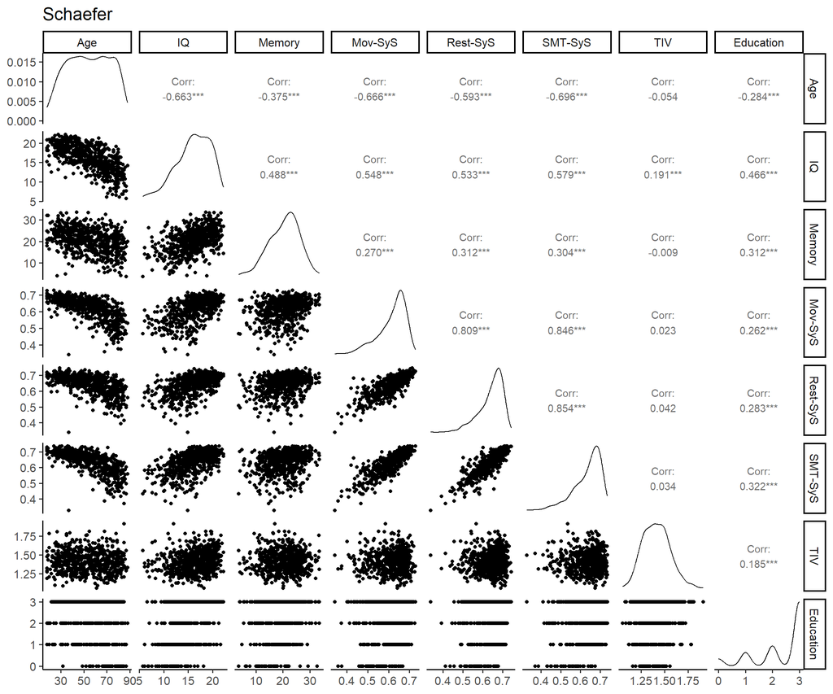

```r
temp_df = with(data = df_Schafer, data.frame(age,CattellPCA,Memory_700,Mov_SyS,Rest_SyS,SMT_SyS,TIV,Education))

colnames(temp_df) <- c('Age','IQ','Memory','Mov-SyS','Rest-SyS','SMT-SyS','TIV','Education')
ggpairs(temp_df,
        lower = list(continuous = "points", combo = "dot_no_facet"),progress=FALSE,title='Schaefer') + theme_classic(base_size=15)
```

```r
ggsave(file.path('./data_for_figures/Main',"TIV_Education.png"), width = 35, height = 25, units = 'cm', dpi = 300);
```

Make polynomial term for age

```r
df_Schafer$ageQuad <- poly(df_Schafer$age,2) #1st linear, 2nd quad
df_Schafer$agepoly_1  = df_Schafer$ageQuad[,1]
df_Schafer$agepoly_2 = df_Schafer$ageQuad[,2]

df_Schafer$agepoly_1z  = datawizard::standardise(df_Schafer$agepoly_1)
df_Schafer$agepoly_2z =  datawizard::standardise(df_Schafer$agepoly_2)
```

**1.a) Predicting SyS from Age and Sex in full Sample. Table 1**

```r
#Rest
lm_model_Rest <- lm(Rest_SyS~ agepoly_1z + agepoly_2z + SexC + agepoly_1z:SexC + agepoly_2z:SexC,
                 data = df_Schafer);

summary(lm_model_Rest)
```

```
##
## Call:
## lm(formula = Rest_SyS ~ agepoly_1z + agepoly_2z + SexC + agepoly_1z:SexC +
##     agepoly_2z:SexC, data = df_Schafer)
##
## Residuals:
##      Min       1Q   Median       3Q      Max
## -0.33800 -0.02486  0.00527  0.03190  0.11482
##
## Coefficients:
##                   Estimate Std. Error t value Pr(>|t|)
## (Intercept)      0.6419064  0.0019535 328.592  < 2e-16 ***
## agepoly_1z      -0.0365719  0.0019559 -18.698  < 2e-16 ***
## agepoly_2z      -0.0094583  0.0019553  -4.837 1.66e-06 ***
## SexC             0.0004413  0.0019535   0.226    0.821
## agepoly_1z:SexC -0.0007707  0.0019559  -0.394    0.694
## agepoly_2z:SexC -0.0004979  0.0019553  -0.255    0.799
## ---
## Signif. codes:  0 '***' 0.001 '**' 0.01 '*' 0.05 '.' 0.1 ' ' 1
##
## Residual standard error: 0.04889 on 621 degrees of freedom
## Multiple R-squared:  0.3758, Adjusted R-squared:  0.3708
## F-statistic: 74.78 on 5 and 621 DF,  p-value: < 2.2e-16
```

```r
etasq(lm_model_Rest,anova=FALSE,partial = TRUE)
```

```
##                 Partial eta^2
## agepoly_1z       3.603148e-01
## agepoly_2z       3.636276e-02
## SexC             8.221263e-05
## agepoly_1z:SexC  2.499298e-04
## agepoly_2z:SexC  1.043932e-04
## Residuals                  NA
```

```r
linearHypothesis(lm_model_Rest,c('agepoly_1z=0','agepoly_2z=0'))
```

```
## Linear hypothesis test
##
## Hypothesis:
## agepoly_1z = 0
## agepoly_2z = 0
##
## Model 1: restricted model
## Model 2: Rest_SyS ~ agepoly_1z + agepoly_2z + SexC + agepoly_1z:SexC +
##     agepoly_2z:SexC
##
##   Res.Df    RSS Df Sum of Sq      F    Pr(>F)
## 1    623 2.3768
## 2    621 1.4846  2   0.89216 186.59 < 2.2e-16 ***
## ---
## Signif. codes:  0 '***' 0.001 '**' 0.01 '*' 0.05 '.' 0.1 ' ' 1
```

```r
# Movie
lm_model_Movie <- lm(Mov_SyS ~ agepoly_1z + agepoly_2z + SexC + agepoly_1z:SexC + agepoly_2z:SexC,
                 data = df_Schafer);

summary(lm_model_Movie)
```

```
##
## Call:
## lm(formula = Mov_SyS ~ agepoly_1z + agepoly_2z + SexC + agepoly_1z:SexC +
##     agepoly_2z:SexC, data = df_Schafer)
##
## Residuals:
##      Min       1Q   Median       3Q      Max
## -0.31635 -0.02377  0.00645  0.02964  0.12212
##
## Coefficients:
##                   Estimate Std. Error t value Pr(>|t|)
## (Intercept)      0.6163288  0.0019974 308.564  < 2e-16 ***
## agepoly_1z      -0.0454595  0.0019999 -22.731  < 2e-16 ***
## agepoly_2z      -0.0108376  0.0019993  -5.421  8.5e-08 ***
## SexC             0.0015817  0.0019974   0.792    0.429
## agepoly_1z:SexC -0.0003821  0.0019999  -0.191    0.849
## agepoly_2z:SexC -0.0008270  0.0019993  -0.414    0.679
## ---
## Signif. codes:  0 '***' 0.001 '**' 0.01 '*' 0.05 '.' 0.1 ' ' 1
##
## Residual standard error: 0.04999 on 621 degrees of freedom
## Multiple R-squared:  0.4689, Adjusted R-squared:  0.4646
## F-statistic: 109.7 on 5 and 621 DF,  p-value: < 2.2e-16
```

```r
etasq(lm_model_Movie,anova=FALSE,partial = TRUE)
```

```
##                 Partial eta^2
## agepoly_1z       4.542285e-01
## agepoly_2z       4.527170e-02
## SexC             1.009443e-03
## agepoly_1z:SexC  5.877863e-05
## agepoly_2z:SexC  2.754844e-04
## Residuals                  NA
```

```r
linearHypothesis(lm_model_Movie,c('agepoly_1z=0','agepoly_2z=0'))
```

```
## Linear hypothesis test
##
## Hypothesis:
## agepoly_1z = 0
## agepoly_2z = 0
##
## Model 1: restricted model
## Model 2: Mov_SyS ~ agepoly_1z + agepoly_2z + SexC + agepoly_1z:SexC +
##     agepoly_2z:SexC
##
##   Res.Df    RSS Df Sum of Sq      F    Pr(>F)
## 1    623 2.9175
## 2    621 1.5521  2    1.3654 273.16 < 2.2e-16 ***
## ---
## Signif. codes:  0 '***' 0.001 '**' 0.01 '*' 0.05 '.' 0.1 ' ' 1
```

```r
# SMT
lm_model_SMT <- lm(SMT_SyS ~ agepoly_1z + agepoly_2z + SexC + agepoly_1z:SexC + agepoly_2z:SexC,
                 data = df_Schafer);

summary(lm_model_SMT)
```

```
##
## Call:
## lm(formula = SMT_SyS ~ agepoly_1z + agepoly_2z + SexC + agepoly_1z:SexC +
##     agepoly_2z:SexC, data = df_Schafer)
##
## Residuals:
##      Min       1Q   Median       3Q      Max
## -0.35745 -0.02197  0.00546  0.02866  0.13055
##
## Coefficients:
##                   Estimate Std. Error t value Pr(>|t|)
## (Intercept)      6.362e-01  1.951e-03 326.029  < 2e-16 ***
## agepoly_1z      -4.831e-02  1.954e-03 -24.725  < 2e-16 ***
## agepoly_2z      -1.056e-02  1.953e-03  -5.404  9.3e-08 ***
## SexC            -8.842e-04  1.951e-03  -0.453    0.651
## agepoly_1z:SexC -1.253e-07  1.954e-03   0.000    1.000
## agepoly_2z:SexC  2.043e-03  1.953e-03   1.046    0.296
## ---
## Signif. codes:  0 '***' 0.001 '**' 0.01 '*' 0.05 '.' 0.1 ' ' 1
##
## Residual standard error: 0.04884 on 621 degrees of freedom
## Multiple R-squared:  0.509,  Adjusted R-squared:  0.505
## F-statistic: 128.8 on 5 and 621 DF,  p-value: < 2.2e-16
```

```r
etasq(lm_model_SMT,anova=FALSE,partial = TRUE)
```

```
##                 Partial eta^2
## agepoly_1z       4.961040e-01
## agepoly_2z       4.471027e-02
## SexC             3.318815e-04
## agepoly_1z:SexC  6.627318e-12
## agepoly_2z:SexC  1.758608e-03
## Residuals                  NA
```

```r
linearHypothesis(lm_model_SMT,c('agepoly_1z=0','agepoly_2z=0'))
```

```
## Linear hypothesis test
##
## Hypothesis:
## agepoly_1z = 0
## agepoly_2z = 0
##
## Model 1: restricted model
## Model 2: SMT_SyS ~ agepoly_1z + agepoly_2z + SexC + agepoly_1z:SexC +
##     agepoly_2z:SexC
##
##   Res.Df    RSS Df Sum of Sq     F    Pr(>F)
## 1    623 3.0101
## 2    621 1.4815  2    1.5287 320.4 < 2.2e-16 ***
## ---
## Signif. codes:  0 '***' 0.001 '**' 0.01 '*' 0.05 '.' 0.1 ' ' 1
```

**1.b) Age effects with robust regression**

```r
# Rest
Rlm_model_Rest <- rlm(scale(Rest_SyS) ~ agepoly_1z + agepoly_2z + SexC + agepoly_1z:SexC + agepoly_2z:SexC,
                 data = df_Schafer);
summary(Rlm_model_Rest)
```

```
##
## Call: rlm(formula = scale(Rest_SyS) ~ agepoly_1z + agepoly_2z + SexC +
##     agepoly_1z:SexC + agepoly_2z:SexC, data = df_Schafer)
## Residuals:
##      Min       1Q   Median       3Q      Max
## -5.54416 -0.44959  0.03024  0.46242  1.80517
##
## Coefficients:
##                 Value    Std. Error t value
## (Intercept)       0.0591   0.0287     2.0630
## agepoly_1z       -0.5732   0.0287   -19.9790
## agepoly_2z       -0.1534   0.0287    -5.3479
## SexC              0.0040   0.0287     0.1388
## agepoly_1z:SexC   0.0035   0.0287     0.1212
## agepoly_2z:SexC   0.0050   0.0287     0.1749
##
## Residual standard error: 0.6854 on 621 degrees of freedom
```

```r
#Movie
Rlm_model_Movie <- rlm(scale(Mov_SyS) ~ agepoly_1z + agepoly_2z + SexC + agepoly_1z:SexC + agepoly_2z:SexC,
                 data = df_Schafer);
summary(Rlm_model_Movie)
```

```
##
## Call: rlm(formula = scale(Mov_SyS) ~ agepoly_1z + agepoly_2z + SexC +
##     agepoly_1z:SexC + agepoly_2z:SexC, data = df_Schafer)
## Residuals:
##      Min       1Q   Median       3Q      Max
## -4.67948 -0.39940  0.03815  0.37514  1.76375
##
## Coefficients:
##                 Value    Std. Error t value
## (Intercept)       0.0567   0.0261     2.1721
## agepoly_1z       -0.6465   0.0261   -24.7313
## agepoly_2z       -0.1625   0.0261    -6.2175
## SexC              0.0342   0.0261     1.3099
## agepoly_1z:SexC   0.0153   0.0261     0.5841
## agepoly_2z:SexC  -0.0045   0.0261    -0.1738
##
## Residual standard error: 0.5709 on 621 degrees of freedom
```

```r
# SMT
Rlm_model_SMT <- rlm(scale(SMT_SyS) ~ agepoly_1z + agepoly_2z + SexC + agepoly_1z:SexC + agepoly_2z:SexC,
                 data = df_Schafer);
summary(Rlm_model_SMT)
```

```
##
## Call: rlm(formula = scale(SMT_SyS) ~ agepoly_1z + agepoly_2z + SexC +
##     agepoly_1z:SexC + agepoly_2z:SexC, data = df_Schafer)
## Residuals:
##      Min       1Q   Median       3Q      Max
## -5.19600 -0.36415  0.03633  0.35890  1.78025
##
## Coefficients:
##                 Value    Std. Error t value
## (Intercept)       0.0591   0.0240     2.4584
## agepoly_1z       -0.6680   0.0241   -27.7484
## agepoly_2z       -0.1505   0.0241    -6.2521
## SexC             -0.0296   0.0240    -1.2305
## agepoly_1z:SexC  -0.0004   0.0241    -0.0151
## agepoly_2z:SexC   0.0178   0.0241     0.7398
##
## Residual standard error: 0.5356 on 621 degrees of freedom
```

**Figures for effect of Age**

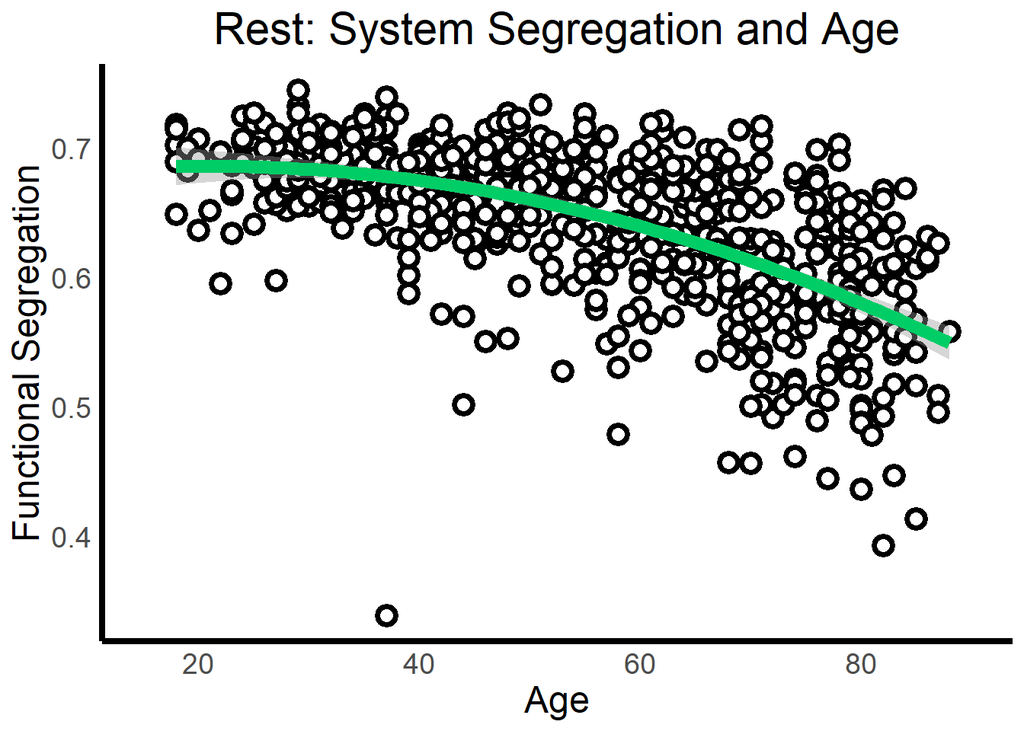

```r
### REST

p <- ggplot(df_Schafer, aes(x = age, y = Rest_SyS))
p <- p + geom_point(shape = 21, size = 3, colour = "black", fill = "white", stroke = 2)
p <- p + stat_smooth(method = "lm", se = TRUE, fill = "grey60", formula = y ~ poly(x,2, raw = TRUE), colour = "springgreen3", size = 3)
#formatting
p <- p + scale_x_continuous(breaks = round(seq(20, max(80), by = 20),1),limits = c(15,90)) + #ylim(0,400) +
  theme_bw() + theme(panel.border = element_blank(), legend.position = "none",text = element_text(size=18),
        panel.grid.major = element_blank(), panel.grid.minor = element_blank(), axis.line = element_line(colour = "black",size = 1.5),axis.ticks = element_blank()) + labs(x='Age',y='Functional Segregation',title='Rest: System Segregation and Age') + theme(plot.title = element_text(hjust = 0.5))
p
```

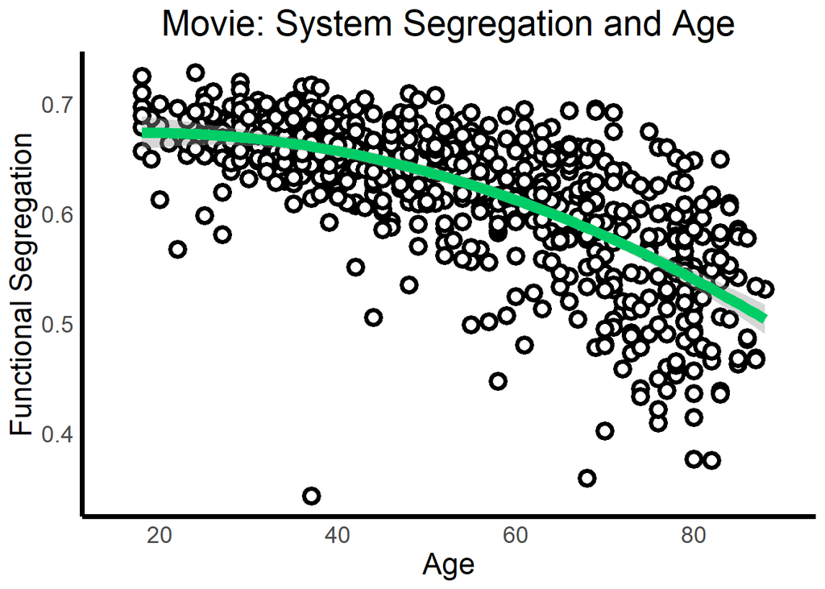

```r
### MOVIE
p <- ggplot(df_Schafer, aes(x = age, y = Mov_SyS ))
p <- p + geom_point(shape = 21, size = 3, colour = "black", fill = "white", stroke = 2)
p <- p + stat_smooth(method = "lm", se = TRUE, fill = "grey60", formula = y ~ poly(x,2, raw = TRUE), colour = "springgreen3", size = 3)
#formatting
p <- p + scale_x_continuous(breaks = round(seq(20, max(80), by = 20),1),limits = c(15,90)) + #ylim(0,400) +
  theme_bw() + theme(panel.border = element_blank(), legend.position = "none",text = element_text(size=18),
        panel.grid.major = element_blank(), panel.grid.minor = element_blank(), axis.line = element_line(colour = "black",size = 1.5),axis.ticks = element_blank()) + labs(x='Age',y='Functional Segregation',title='Movie: System Segregation and Age') +theme(plot.title = element_text(hjust = 0.5))
p
```

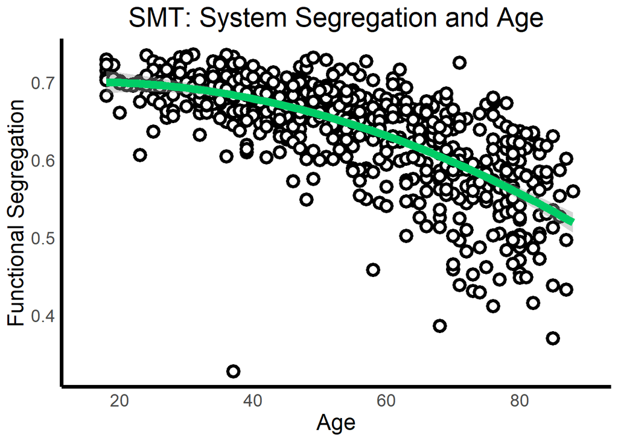

```r
###SMT

p <- ggplot(df_Schafer, aes(x = age, y = SMT_SyS))
p <- p + geom_point(shape = 21, size = 3, colour ="black", fill = "white", stroke = 2)
p <- p + stat_smooth(method = "lm", se = TRUE, fill = "grey60", formula = y ~ poly(x,2, raw = TRUE), colour = "springgreen3", size = 3)
#formatting
p <- p + scale_x_continuous(breaks = round(seq(20, max(80), by = 20),1),limits = c(15,90)) + #ylim(0,400) +
  theme_bw() + theme(panel.border = element_blank(), legend.position = "none",text = element_text(size=18),
        panel.grid.major = element_blank(), panel.grid.minor = element_blank(), axis.line = element_line(colour = "black",size = 1.5),axis.ticks = element_blank()) + labs(x='Age',y='Functional Segregation',title='SMT: System Segregation and Age') +theme(plot.title = element_text(hjust = 0.5))
p
```

**2.a) Predicting Fluid Intelligence from SyS after accounting for Age and Sex. - Table 2**

```r
# REST
lm_model_R <- lm(CattellPCA ~ scale(Rest_SyS)*agepoly_1z*SexC + scale(Rest_SyS)*agepoly_2z*SexC,
                 data = df_Schafer);

summary(lm_model_R)
```

```
##
## Call:
## lm(formula = CattellPCA ~ scale(Rest_SyS) * agepoly_1z * SexC +
##     scale(Rest_SyS) * agepoly_2z * SexC, data = df_Schafer)
##
## Residuals:
##     Min      1Q  Median      3Q     Max
## -8.0065 -1.5448  0.1171  1.7522  6.8928
##
## Coefficients:
##                                 Estimate Std. Error t value Pr(>|t|)
## (Intercept)                     16.00910    0.12619 126.866  < 2e-16 ***
## scale(Rest_SyS)                  0.73130    0.13836   5.285 1.75e-07 ***
## agepoly_1z                      -1.90001    0.14034 -13.539  < 2e-16 ***
## SexC                            -0.41337    0.12619  -3.276  0.00111 **
## agepoly_2z                      -0.52051    0.11984  -4.343 1.64e-05 ***
## scale(Rest_SyS):agepoly_1z      -0.19772    0.14676  -1.347  0.17838
## scale(Rest_SyS):SexC            -0.08738    0.13836  -0.632  0.52793
## agepoly_1z:SexC                 -0.01100    0.14034  -0.078  0.93753
## scale(Rest_SyS):agepoly_2z      -0.11196    0.11714  -0.956  0.33957
## SexC:agepoly_2z                 -0.13931    0.11984  -1.162  0.24553
## scale(Rest_SyS):agepoly_1z:SexC -0.30056    0.14676  -2.048  0.04098 *
## scale(Rest_SyS):SexC:agepoly_2z  0.04099    0.11714   0.350  0.72651
## ---
## Signif. codes:  0 '***' 0.001 '**' 0.01 '*' 0.05 '.' 0.1 ' ' 1
##
## Residual standard error: 2.416 on 615 degrees of freedom
## Multiple R-squared:  0.5002, Adjusted R-squared:  0.4912
## F-statistic: 55.94 on 11 and 615 DF,  p-value: < 2.2e-16
```

```r
etasq(lm_model_R,anova=FALSE,partial = TRUE)
```

```
##                                 Partial eta^2
## scale(Rest_SyS)                  0.0420887892
## agepoly_1z                       0.2673797908
## SexC                             0.0100506617
## agepoly_2z                       0.0338533339
## scale(Rest_SyS):agepoly_1z       0.0018382471
## scale(Rest_SyS):SexC             0.0051004986
## agepoly_1z:SexC                  0.0011177772
## scale(Rest_SyS):agepoly_2z       0.0015083302
## SexC:agepoly_2z                  0.0020033713
## scale(Rest_SyS):agepoly_1z:SexC  0.0067741573
## scale(Rest_SyS):SexC:agepoly_2z  0.0001990714
## Residuals                                  NA
```

```r
# MOVIE
lm_model_M <- lm(CattellPCA ~ scale(Mov_SyS)*agepoly_1z*SexC + scale(Mov_SyS)*agepoly_2z*SexC,
                 data = df_Schafer);

summary(lm_model_M)
```

```
##
## Call:
## lm(formula = CattellPCA ~ scale(Mov_SyS) * agepoly_1z * SexC +
##     scale(Mov_SyS) * agepoly_2z * SexC, data = df_Schafer)
##
## Residuals:
##     Min      1Q  Median      3Q     Max
## -8.0098 -1.5922  0.1145  1.7964  6.0411
##
## Coefficients:
##                                Estimate Std. Error t value Pr(>|t|)
## (Intercept)                    16.04076    0.14161 113.277  < 2e-16 ***
## scale(Mov_SyS)                  0.60170    0.15441   3.897 0.000108 ***
## agepoly_1z                     -1.93255    0.15815 -12.219  < 2e-16 ***
## SexC                           -0.27822    0.14161  -1.965 0.049893 *
## agepoly_2z                     -0.50527    0.13203  -3.827 0.000143 ***
## scale(Mov_SyS):agepoly_1z      -0.13875    0.16115  -0.861 0.389574
## scale(Mov_SyS):SexC            -0.18044    0.15441  -1.169 0.243013
## agepoly_1z:SexC                -0.10541    0.15815  -0.667 0.505335
## scale(Mov_SyS):agepoly_2z      -0.10384    0.11965  -0.868 0.385799
## SexC:agepoly_2z                -0.01222    0.13203  -0.093 0.926300
## scale(Mov_SyS):agepoly_1z:SexC -0.03240    0.16115  -0.201 0.840714
## scale(Mov_SyS):SexC:agepoly_2z -0.04806    0.11965  -0.402 0.688073
## ---
## Signif. codes:  0 '***' 0.001 '**' 0.01 '*' 0.05 '.' 0.1 ' ' 1
##
## Residual standard error: 2.45 on 615 degrees of freedom
## Multiple R-squared:  0.4859, Adjusted R-squared:  0.4767
## F-statistic: 52.84 on 11 and 615 DF,  p-value: < 2.2e-16
```

```r
etasq(lm_model_M,anova=FALSE,partial = TRUE)
```

```
##                                Partial eta^2
## scale(Mov_SyS)                  2.541466e-02
## agepoly_1z                      2.281567e-01
## SexC                            1.040679e-02
## agepoly_2z                      2.746409e-02
## scale(Mov_SyS):agepoly_1z       1.160089e-03
## scale(Mov_SyS):SexC             3.545192e-03
## agepoly_1z:SexC                 1.034644e-03
## scale(Mov_SyS):agepoly_2z       1.338773e-03
## SexC:agepoly_2z                 6.150349e-05
## scale(Mov_SyS):agepoly_1z:SexC  6.573073e-05
## scale(Mov_SyS):SexC:agepoly_2z  2.622582e-04
## Residuals                                 NA
```

```r
# SMT
lm_model_S <- lm(CattellPCA ~ scale(SMT_SyS)*agepoly_1z*SexC + scale(SMT_SyS)*agepoly_2z*SexC,
                 data = df_Schafer);

summary(lm_model_S)
```

```
##
## Call:
## lm(formula = CattellPCA ~ scale(SMT_SyS) * agepoly_1z * SexC +
##     scale(SMT_SyS) * agepoly_2z * SexC, data = df_Schafer)
##
## Residuals:
##     Min      1Q  Median      3Q     Max
## -8.0316 -1.6429  0.0515  1.7795  6.4291
##
## Coefficients:
##                                Estimate Std. Error t value Pr(>|t|)
## (Intercept)                    16.15883    0.15389 105.005  < 2e-16 ***
## scale(SMT_SyS)                  0.58541    0.16922   3.459 0.000579 ***
## agepoly_1z                     -1.98398    0.17381 -11.415  < 2e-16 ***
## SexC                           -0.31967    0.15389  -2.077 0.038187 *
## agepoly_2z                     -0.36636    0.14175  -2.585 0.009978 **
## scale(SMT_SyS):agepoly_1z       0.07346    0.18227   0.403 0.687085
## scale(SMT_SyS):SexC            -0.23692    0.16922  -1.400 0.162001
## agepoly_1z:SexC                -0.14454    0.17381  -0.832 0.405974
## scale(SMT_SyS):agepoly_2z      -0.23822    0.12317  -1.934 0.053554 .
## SexC:agepoly_2z                -0.10151    0.14175  -0.716 0.474176
## scale(SMT_SyS):agepoly_1z:SexC -0.14049    0.18227  -0.771 0.441147
## scale(SMT_SyS):SexC:agepoly_2z -0.02254    0.12317  -0.183 0.854848
## ---
## Signif. codes:  0 '***' 0.001 '**' 0.01 '*' 0.05 '.' 0.1 ' ' 1
##
## Residual standard error: 2.434 on 615 degrees of freedom
## Multiple R-squared:  0.4929, Adjusted R-squared:  0.4838
## F-statistic: 54.34 on 11 and 615 DF,  p-value: < 2.2e-16
```

```r
etasq(lm_model_S,anova=FALSE,partial = TRUE)
```

```
##                                Partial eta^2
## scale(SMT_SyS)                  3.318093e-02
## agepoly_1z                      2.077647e-01
## SexC                            8.208133e-03
## agepoly_2z                      1.803917e-02
## scale(SMT_SyS):agepoly_1z       6.957470e-04
## scale(SMT_SyS):SexC             7.732767e-03
## agepoly_1z:SexC                 2.942085e-03
## scale(SMT_SyS):agepoly_2z       5.996391e-03
## SexC:agepoly_2z                 1.107062e-03
## scale(SMT_SyS):agepoly_1z:SexC  9.650289e-04
## scale(SMT_SyS):SexC:agepoly_2z  5.445843e-05
## Residuals                                 NA
```

```r
X1<- Plot_regression_SyS(lm_model_R,terms='Rest_SyS',TITLE='Rest',XLAB='Rest-SyS',YLAB='Adjusted Fluid Intelligence',COND = list(agepoly_1z=0,agepoly_2z=0,SexC=0),TYPE='contrast')
```

```
## Conditions used in construction of plot
## agepoly_1z: 0
## SexC: 0
## agepoly_2z: 0
```

```r
X2 <-Plot_regression_SyS(lm_model_M,terms='Mov_SyS',TITLE='Movie',XLAB='Movie-SyS',COND = list(agepoly_1z=0,agepoly_2z=0,SexC=0),TYPE='contrast')
```

```
## Conditions used in construction of plot
## agepoly_1z: 0
## SexC: 0
## agepoly_2z: 0
```

```r
X3<-Plot_regression_SyS(lm_model_S,terms='SMT_SyS',TITLE='SMT',XLAB='SMT-SyS',COND = list(agepoly_1z=0,agepoly_2z=0,SexC=0),TYPE='contrast')
```

```
## Conditions used in construction of plot
## agepoly_1z: 0
## SexC: 0
## agepoly_2z: 0
```

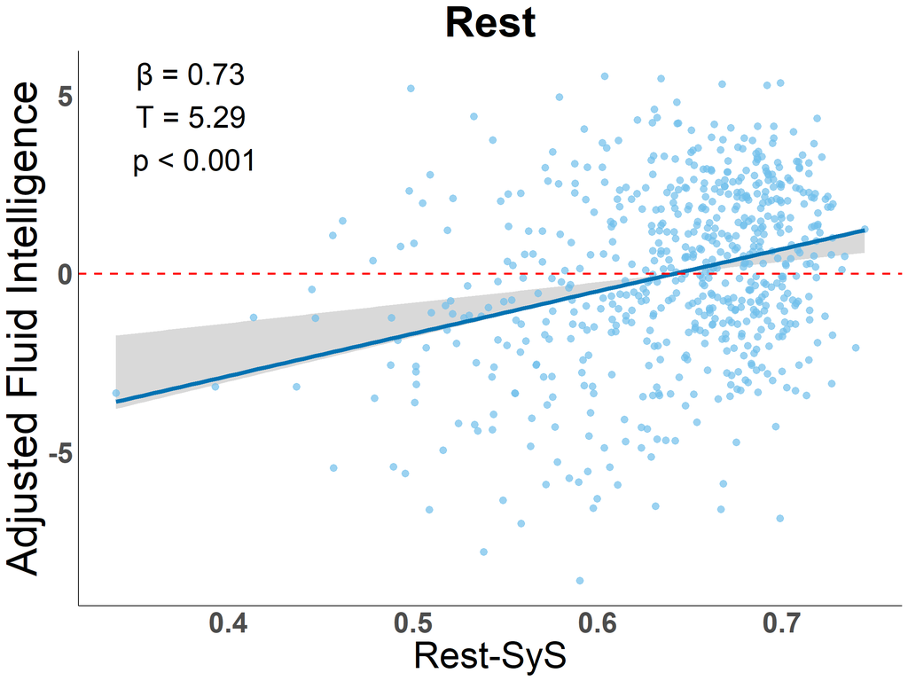

```r
REGPLOTS <- do.call("arrangeGrob", c(X1[1],X2[1],X3[1], ncol = 3))
ggsave('./data_for_figures/Main/Fluid_Intelligence_SyS.png',REGPLOTS, width = 24, height = 8)


plot(X1[[1]])
```

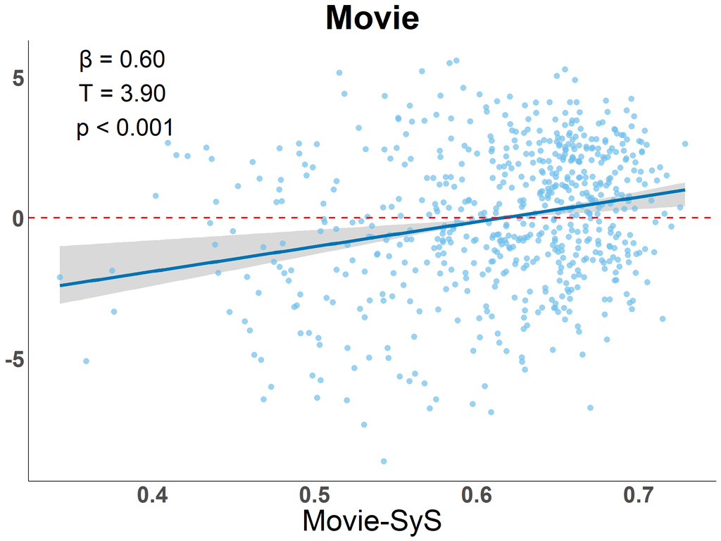

```r
plot(X2[[1]])
```

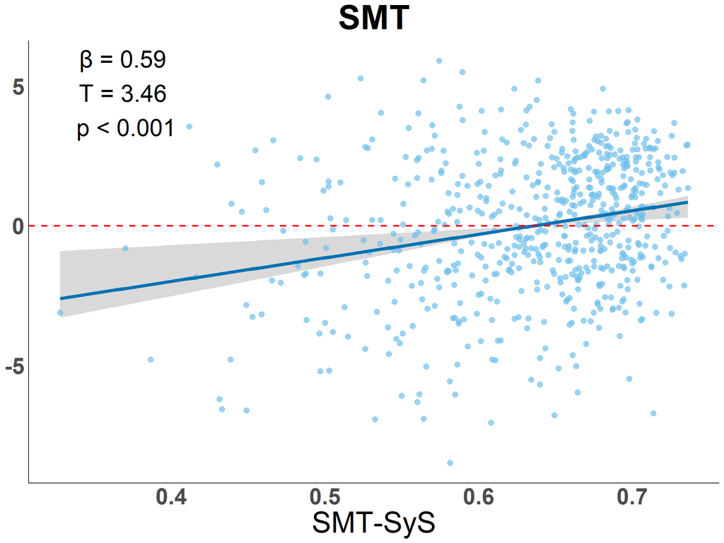

```r
plot(X3[[1]])
```

**2.b) Effect for Fluid Intelligence with robust regression**

```r
rlm_model_R <- rlm(CattellPCA ~ scale(Rest_SyS)*agepoly_1z*SexC + scale(Rest_SyS)*agepoly_2z*SexC,
                 data = df_Schafer); summary(rlm_model_R)
```

```
##
## Call: rlm(formula = CattellPCA ~ scale(Rest_SyS) * agepoly_1z * SexC +
##     scale(Rest_SyS) * agepoly_2z * SexC, data = df_Schafer)
## Residuals:
##      Min       1Q   Median       3Q      Max
## -8.00250 -1.61161  0.07546  1.68019  6.96880
##
## Coefficients:
##                                 Value    Std. Error t value
## (Intercept)                      16.1038   0.1310   122.9524
## scale(Rest_SyS)                   0.7146   0.1436     4.9761
## agepoly_1z                       -1.9166   0.1457   -13.1580
## SexC                             -0.4072   0.1310    -3.1091
## agepoly_2z                       -0.4645   0.1244    -3.7346
## scale(Rest_SyS):agepoly_1z       -0.1336   0.1523    -0.8771
## scale(Rest_SyS):SexC             -0.1342   0.1436    -0.9345
## agepoly_1z:SexC                  -0.0380   0.1457    -0.2608
## scale(Rest_SyS):agepoly_2z       -0.1459   0.1216    -1.2003
## SexC:agepoly_2z                  -0.1483   0.1244    -1.1926
## scale(Rest_SyS):agepoly_1z:SexC  -0.3144   0.1523    -2.0641
## scale(Rest_SyS):SexC:agepoly_2z   0.0345   0.1216     0.2836
##
## Residual standard error: 2.438 on 615 degrees of freedom
```

```r
rlm_model_M <- rlm(CattellPCA ~ scale(Mov_SyS)*agepoly_1z*SexC + scale(Mov_SyS)*agepoly_2z*SexC,
                 data = df_Schafer); summary(rlm_model_M)
```

```
##
## Call: rlm(formula = CattellPCA ~ scale(Mov_SyS) * agepoly_1z * SexC +
##     scale(Mov_SyS) * agepoly_2z * SexC, data = df_Schafer)
## Residuals:
##      Min       1Q   Median       3Q      Max
## -8.05111 -1.63551  0.02266  1.74497  6.00789
##
## Coefficients:
##                                Value    Std. Error t value
## (Intercept)                     16.1519   0.1467   110.1290
## scale(Mov_SyS)                   0.5492   0.1599     3.4343
## agepoly_1z                      -1.9686   0.1638   -12.0184
## SexC                            -0.2416   0.1467    -1.6471
## agepoly_2z                      -0.4539   0.1367    -3.3192
## scale(Mov_SyS):agepoly_1z       -0.0675   0.1669    -0.4041
## scale(Mov_SyS):SexC             -0.2414   0.1599    -1.5098
## agepoly_1z:SexC                 -0.1652   0.1638    -1.0087
## scale(Mov_SyS):agepoly_2z       -0.1253   0.1239    -1.0109
## SexC:agepoly_2z                  0.0119   0.1367     0.0869
## scale(Mov_SyS):agepoly_1z:SexC  -0.0032   0.1669    -0.0190
## scale(Mov_SyS):SexC:agepoly_2z  -0.0727   0.1239    -0.5871
##
## Residual standard error: 2.568 on 615 degrees of freedom
```

```r
rlm_model_S <- rlm(CattellPCA ~ scale(SMT_SyS)*agepoly_1z*SexC + scale(SMT_SyS)*agepoly_2z*SexC,
                 data = df_Schafer); summary(rlm_model_S)
```

```
##
## Call: rlm(formula = CattellPCA ~ scale(SMT_SyS) * agepoly_1z * SexC +
##     scale(SMT_SyS) * agepoly_2z * SexC, data = df_Schafer)
## Residuals:
##       Min        1Q    Median        3Q       Max
## -7.987730 -1.665912  0.006581  1.716782  6.502781
##
## Coefficients:
##                                Value    Std. Error t value
## (Intercept)                     16.2368   0.1563   103.8896
## scale(SMT_SyS)                   0.5934   0.1719     3.4528
## agepoly_1z                      -2.0114   0.1765   -11.3944
## SexC                            -0.3141   0.1563    -2.0097
## agepoly_2z                      -0.3152   0.1440    -2.1893
## scale(SMT_SyS):agepoly_1z        0.1195   0.1851     0.6455
## scale(SMT_SyS):SexC             -0.2622   0.1719    -1.5258
## agepoly_1z:SexC                 -0.1504   0.1765    -0.8519
## scale(SMT_SyS):agepoly_2z       -0.2759   0.1251    -2.2060
## SexC:agepoly_2z                 -0.1017   0.1440    -0.7063
## scale(SMT_SyS):agepoly_1z:SexC  -0.1701   0.1851    -0.9191
## scale(SMT_SyS):SexC:agepoly_2z  -0.0138   0.1251    -0.1103
##
## Residual standard error: 2.529 on 615 degrees of freedom
```

**3.a) Predicting Episodic Memory from SyS in full sample. Table 3**

```r
Mem_lm_model_R <- lm(Memory_700 ~ scale(Rest_SyS)*agepoly_1z*SexC + scale(Rest_SyS)*agepoly_2z*SexC,
                 data = df_Schafer);

summary(Mem_lm_model_R)
```

```
##
## Call:
## lm(formula = Memory_700 ~ scale(Rest_SyS) * agepoly_1z * SexC +
##     scale(Rest_SyS) * agepoly_2z * SexC, data = df_Schafer)
##
## Residuals:
##      Min       1Q   Median       3Q      Max
## -18.8862  -3.2014   0.4096   3.5129  13.7765
##
## Coefficients:
##                                 Estimate Std. Error t value Pr(>|t|)
## (Intercept)                     20.36821    0.26781  76.053  < 2e-16 ***
## scale(Rest_SyS)                  0.85327    0.29366   2.906   0.0038 **
## agepoly_1z                      -1.69615    0.29784  -5.695 1.91e-08 ***
## SexC                             0.79806    0.26781   2.980   0.0030 **
## agepoly_2z                      -0.21411    0.25435  -0.842   0.4002
## scale(Rest_SyS):agepoly_1z      -0.24536    0.31146  -0.788   0.4311
## scale(Rest_SyS):SexC            -0.08476    0.29366  -0.289   0.7730
## agepoly_1z:SexC                 -0.19752    0.29784  -0.663   0.5075
## scale(Rest_SyS):agepoly_2z      -0.17148    0.24861  -0.690   0.4906
## SexC:agepoly_2z                  0.24756    0.25435   0.973   0.3308
## scale(Rest_SyS):agepoly_1z:SexC  0.15882    0.31146   0.510   0.6103
## scale(Rest_SyS):SexC:agepoly_2z -0.27953    0.24861  -1.124   0.2613
## ---
## Signif. codes:  0 '***' 0.001 '**' 0.01 '*' 0.05 '.' 0.1 ' ' 1
##
## Residual standard error: 5.128 on 615 degrees of freedom
## Multiple R-squared:  0.1769, Adjusted R-squared:  0.1621
## F-statistic: 12.01 on 11 and 615 DF,  p-value: < 2.2e-16
```

```r
etasq(Mem_lm_model_R,anova=FALSE,partial = TRUE)
```

```
##                                 Partial eta^2
## scale(Rest_SyS)                  1.312456e-02
## agepoly_1z                       6.074544e-02
## SexC                             2.112833e-02
## agepoly_2z                       2.093052e-03
## scale(Rest_SyS):agepoly_1z       1.229239e-03
## scale(Rest_SyS):SexC             2.923491e-05
## agepoly_1z:SexC                  4.395645e-04
## scale(Rest_SyS):agepoly_2z       7.178453e-04
## SexC:agepoly_2z                  8.598750e-04
## scale(Rest_SyS):agepoly_1z:SexC  4.225828e-04
## scale(Rest_SyS):SexC:agepoly_2z  2.051453e-03
## Residuals                                  NA
```

```r
Mem_lm_model_M <- lm(Memory_700 ~ scale(Mov_SyS)*agepoly_1z*SexC + scale(Mov_SyS)*agepoly_2z*SexC,
                 data = df_Schafer);

summary(Mem_lm_model_M)
```

```
##
## Call:
## lm(formula = Memory_700 ~ scale(Mov_SyS) * agepoly_1z * SexC +
##     scale(Mov_SyS) * agepoly_2z * SexC, data = df_Schafer)
##
## Residuals:
##      Min       1Q   Median       3Q      Max
## -19.0225  -3.2135   0.3695   3.5448  14.3071
##
## Coefficients:
##                                Estimate Std. Error t value Pr(>|t|)
## (Intercept)                     20.2692     0.2972  68.203  < 2e-16 ***
## scale(Mov_SyS)                   0.2758     0.3241   0.851  0.39510
## agepoly_1z                      -2.0560     0.3319  -6.194 1.07e-09 ***
## SexC                             0.9382     0.2972   3.157  0.00167 **
## agepoly_2z                      -0.3818     0.2771  -1.378  0.16871
## scale(Mov_SyS):agepoly_1z       -0.3757     0.3382  -1.111  0.26708
## scale(Mov_SyS):SexC             -0.4179     0.3241  -1.290  0.19766
## agepoly_1z:SexC                 -0.5423     0.3319  -1.634  0.10284
## scale(Mov_SyS):agepoly_2z       -0.1681     0.2511  -0.669  0.50345
## SexC:agepoly_2z                  0.3537     0.2771   1.276  0.20228
## scale(Mov_SyS):agepoly_1z:SexC   0.4015     0.3382   1.187  0.23560
## scale(Mov_SyS):SexC:agepoly_2z  -0.4741     0.2511  -1.888  0.05949 .
## ---
## Signif. codes:  0 '***' 0.001 '**' 0.01 '*' 0.05 '.' 0.1 ' ' 1
##
## Residual standard error: 5.143 on 615 degrees of freedom
## Multiple R-squared:  0.1722, Adjusted R-squared:  0.1573
## F-statistic: 11.63 on 11 and 615 DF,  p-value: < 2.2e-16
```

```r
etasq(Mem_lm_model_M,anova=FALSE,partial = TRUE)
```

```
##                                Partial eta^2
## scale(Mov_SyS)                  0.0003136488
## agepoly_1z                      0.0747859981
## SexC                            0.0209302657
## agepoly_2z                      0.0047194183
## scale(Mov_SyS):agepoly_1z       0.0024757194
## scale(Mov_SyS):SexC             0.0013225103
## agepoly_1z:SexC                 0.0026772261
## scale(Mov_SyS):agepoly_2z       0.0011567947
## SexC:agepoly_2z                 0.0011695470
## scale(Mov_SyS):agepoly_1z:SexC  0.0022866390
## scale(Mov_SyS):SexC:agepoly_2z  0.0057629375
## Residuals                                 NA
```

```r
Mem_lm_model_S <- lm(Memory_700 ~ scale(SMT_SyS)*agepoly_1z*SexC + scale(SMT_SyS)*agepoly_2z*SexC,
                 data = df_Schafer);

summary(Mem_lm_model_S)
```

```
##
## Call:
## lm(formula = Memory_700 ~ scale(SMT_SyS) * agepoly_1z * SexC +
##     scale(SMT_SyS) * agepoly_2z * SexC, data = df_Schafer)
##
## Residuals:
##      Min       1Q   Median       3Q      Max
## -18.9781  -3.2197   0.4295   3.5654  14.3061
##
## Coefficients:
##                                Estimate Std. Error t value Pr(>|t|)
## (Intercept)                     20.3102     0.3253  62.441  < 2e-16 ***
## scale(SMT_SyS)                   0.4802     0.3577   1.342  0.17993
## agepoly_1z                      -1.8996     0.3674  -5.171 3.16e-07 ***
## SexC                             0.9632     0.3253   2.961  0.00318 **
## agepoly_2z                      -0.3055     0.2996  -1.020  0.30828
## scale(SMT_SyS):agepoly_1z       -0.2932     0.3853  -0.761  0.44701
## scale(SMT_SyS):SexC             -0.4155     0.3577  -1.162  0.24586
## agepoly_1z:SexC                 -0.5086     0.3674  -1.384  0.16673
## scale(SMT_SyS):agepoly_2z       -0.2095     0.2603  -0.805  0.42132
## SexC:agepoly_2z                  0.3464     0.2996   1.156  0.24809
## scale(SMT_SyS):agepoly_1z:SexC   0.3629     0.3853   0.942  0.34656
## scale(SMT_SyS):SexC:agepoly_2z  -0.3886     0.2603  -1.493  0.13605
## ---
## Signif. codes:  0 '***' 0.001 '**' 0.01 '*' 0.05 '.' 0.1 ' ' 1
##
## Residual standard error: 5.144 on 615 degrees of freedom
## Multiple R-squared:  0.1716, Adjusted R-squared:  0.1568
## F-statistic: 11.58 on 11 and 615 DF,  p-value: < 2.2e-16
```

```r
etasq(Mem_lm_model_S,anova=FALSE,partial = TRUE)
```

```
##                                Partial eta^2
## scale(SMT_SyS)                  0.0034378874
## agepoly_1z                      0.0570440228
## SexC                            0.0222293620
## agepoly_2z                      0.0035886900
## scale(SMT_SyS):agepoly_1z       0.0018934331
## scale(SMT_SyS):SexC             0.0010106422
## agepoly_1z:SexC                 0.0018520226
## scale(SMT_SyS):agepoly_2z       0.0006427745
## SexC:agepoly_2z                 0.0007849869
## scale(SMT_SyS):agepoly_1z:SexC  0.0014408168
## scale(SMT_SyS):SexC:agepoly_2z  0.0036095777
## Residuals                                 NA
```

**3.b) Episodic Memory Effects with Robust regression.**

```r
#Rest
Mem_rlm_model_R <- rlm(Memory_700 ~ scale(Rest_SyS)*agepoly_1z*SexC + scale(Rest_SyS)*agepoly_2z*SexC,
                 data = df_Schafer);
summary(Mem_rlm_model_R)
```

```
##
## Call: rlm(formula = Memory_700 ~ scale(Rest_SyS) * agepoly_1z * SexC +
##     scale(Rest_SyS) * agepoly_2z * SexC, data = df_Schafer)
## Residuals:
##      Min       1Q   Median       3Q      Max
## -19.1093  -3.3520   0.2688   3.3348  13.7561
##
## Coefficients:
##                                 Value   Std. Error t value
## (Intercept)                     20.4426  0.2718    75.2251
## scale(Rest_SyS)                  0.8485  0.2980     2.8475
## agepoly_1z                      -1.7782  0.3022    -5.8839
## SexC                             0.8711  0.2718     3.2054
## agepoly_2z                      -0.2603  0.2581    -1.0087
## scale(Rest_SyS):agepoly_1z      -0.3307  0.3160    -1.0463
## scale(Rest_SyS):SexC            -0.1362  0.2980    -0.4570
## agepoly_1z:SexC                 -0.2964  0.3022    -0.9808
## scale(Rest_SyS):agepoly_2z      -0.2297  0.2523    -0.9104
## SexC:agepoly_2z                  0.1832  0.2581     0.7098
## scale(Rest_SyS):agepoly_1z:SexC  0.1059  0.3160     0.3352
## scale(Rest_SyS):SexC:agepoly_2z -0.3425  0.2523    -1.3578
##
## Residual standard error: 4.958 on 615 degrees of freedom
```

```r
# Movie
Mem_rlm_model_M <- rlm(Memory_700 ~ scale(Mov_SyS)*agepoly_1z*SexC + scale(Mov_SyS)*agepoly_2z*SexC,
                 data = df_Schafer);
summary(Mem_rlm_model_M)
```

```
##
## Call: rlm(formula = Memory_700 ~ scale(Mov_SyS) * agepoly_1z * SexC +
##     scale(Mov_SyS) * agepoly_2z * SexC, data = df_Schafer)
## Residuals:
##      Min       1Q   Median       3Q      Max
## -19.4424  -3.4185   0.2768   3.3429  14.4000
##
## Coefficients:
##                                Value   Std. Error t value
## (Intercept)                    20.3064  0.3012    67.4160
## scale(Mov_SyS)                  0.2839  0.3284     0.8645
## agepoly_1z                     -2.1181  0.3364    -6.2962
## SexC                            0.9727  0.3012     3.2294
## agepoly_2z                     -0.4678  0.2808    -1.6657
## scale(Mov_SyS):agepoly_1z      -0.5280  0.3428    -1.5405
## scale(Mov_SyS):SexC            -0.3415  0.3284    -1.0397
## agepoly_1z:SexC                -0.5482  0.3364    -1.6294
## scale(Mov_SyS):agepoly_2z      -0.2147  0.2545    -0.8437
## SexC:agepoly_2z                 0.2675  0.2808     0.9526
## scale(Mov_SyS):agepoly_1z:SexC  0.2660  0.3428     0.7759
## scale(Mov_SyS):SexC:agepoly_2z -0.5186  0.2545    -2.0376
##
## Residual standard error: 5.022 on 615 degrees of freedom
```

```r
# SMT
Mem_rlm_model_S <- rlm(Memory_700 ~ scale(SMT_SyS)*agepoly_1z*SexC + scale(SMT_SyS)*agepoly_2z*SexC,
                 data = df_Schafer);
summary(Mem_rlm_model_S)
```

```
##
## Call: rlm(formula = Memory_700 ~ scale(SMT_SyS) * agepoly_1z * SexC +
##     scale(SMT_SyS) * agepoly_2z * SexC, data = df_Schafer)
## Residuals:
##      Min       1Q   Median       3Q      Max
## -19.5284  -3.3831   0.3257   3.3298  14.3236
##
## Coefficients:
##                                Value   Std. Error t value
## (Intercept)                    20.3665  0.3311    61.5129
## scale(SMT_SyS)                  0.5600  0.3641     1.5380
## agepoly_1z                     -1.8948  0.3740    -5.0667
## SexC                            0.9789  0.3311     2.9566
## agepoly_2z                     -0.3701  0.3050    -1.2136
## scale(SMT_SyS):agepoly_1z      -0.4272  0.3922    -1.0894
## scale(SMT_SyS):SexC            -0.3398  0.3641    -0.9333
## agepoly_1z:SexC                -0.4730  0.3740    -1.2649
## scale(SMT_SyS):agepoly_2z      -0.2310  0.2650    -0.8715
## SexC:agepoly_2z                 0.2319  0.3050     0.7604
## scale(SMT_SyS):agepoly_1z:SexC  0.1894  0.3922     0.4829
## scale(SMT_SyS):SexC:agepoly_2z -0.3632  0.2650    -1.3707
##
## Residual standard error: 4.976 on 615 degrees of freedom
```

```r
X1<- Plot_regression_SyS(Mem_lm_model_R,terms='Rest_SyS',TITLE='Rest',XLAB='Rest-SyS',YLAB='Adjusted Episodic Memory',COND = list(agepoly_1z=0,agepoly_2z=0,SexC=0),TYPE='contrast')
```

```
## Conditions used in construction of plot
## agepoly_1z: 0
## SexC: 0
## agepoly_2z: 0
```

```r
X2 <-Plot_regression_SyS(Mem_lm_model_M,terms='Mov_SyS',TITLE='Movie',XLAB='Movie-SyS',COND = list(agepoly_1z=0,agepoly_2z=0,SexC=0),TYPE='contrast')
```

```
## Conditions used in construction of plot
## agepoly_1z: 0
## SexC: 0
## agepoly_2z: 0
```

```r
X3<-Plot_regression_SyS(Mem_lm_model_S,terms='SMT_SyS',TITLE='SMT',XLAB='SMT-SyS',COND = list(agepoly_1z=0,agepoly_2z=0,SexC=0),TYPE='contrast')
```

```
## Conditions used in construction of plot
## agepoly_1z: 0
## SexC: 0
## agepoly_2z: 0
```

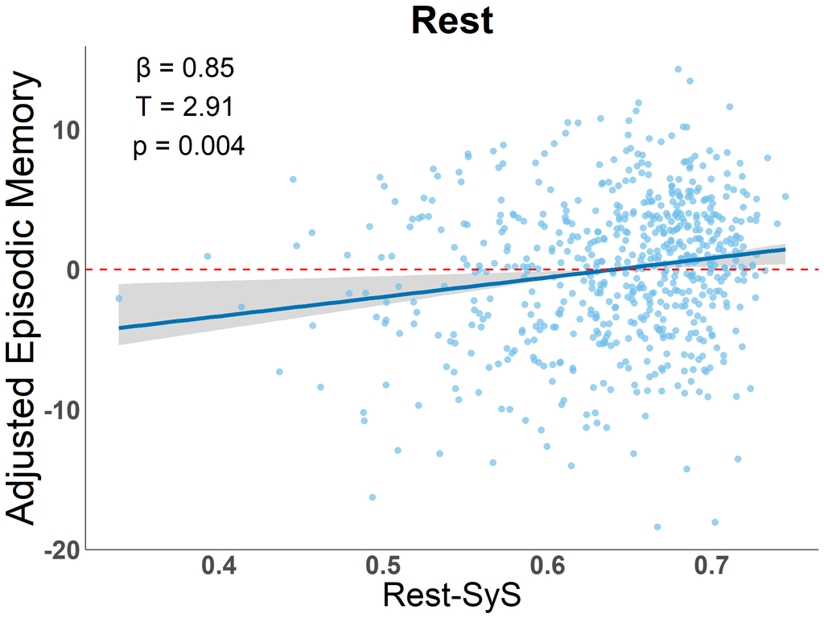

```r
REGPLOTS <- do.call("arrangeGrob", c(X1[1],X2[1],X3[1], ncol = 3))
ggsave('./data_for_figures/Main/Episodic_Memory_SyS.png',REGPLOTS, width = 24, height = 8)


plot(X1[[1]])
```

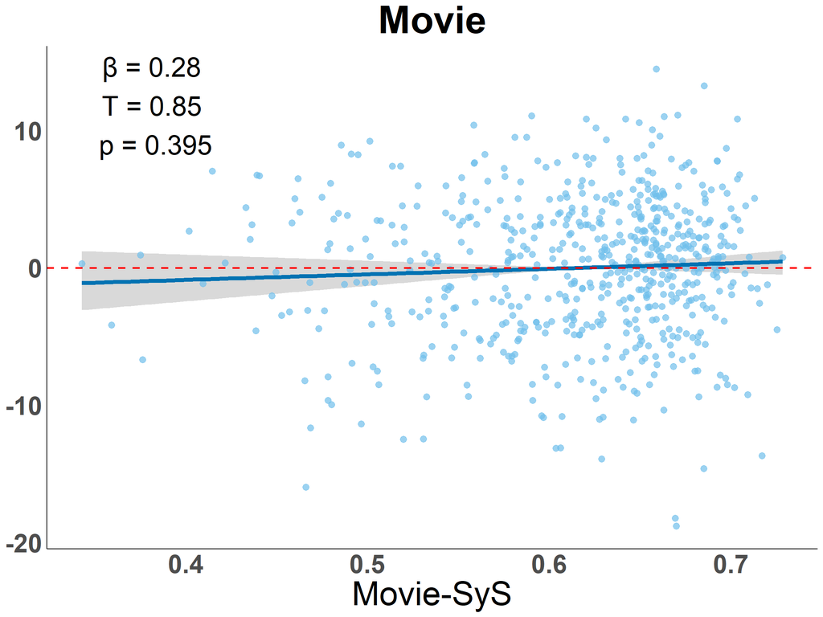

```r
plot(X2[[1]])
```

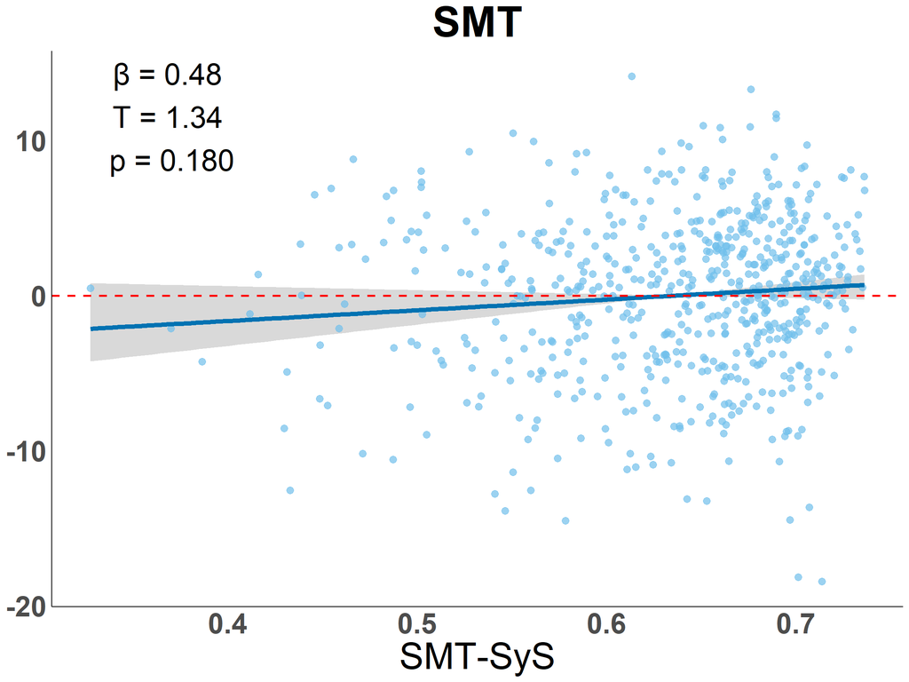

```r
plot(X3[[1]])
```

# IQ and Memory interaction PLOTs

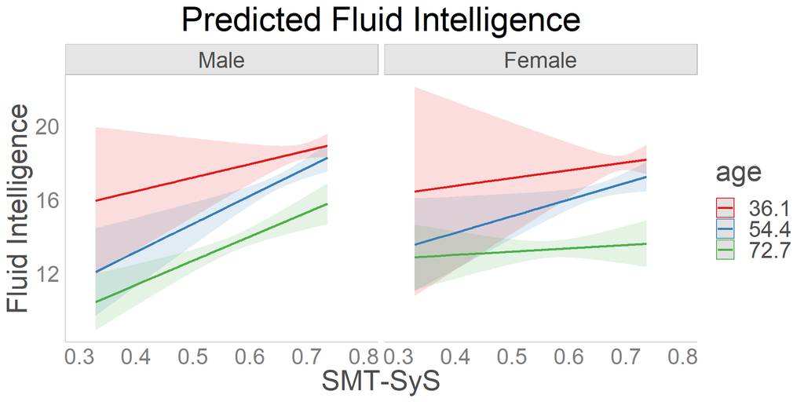

```r
df_main_plot = df_Schafer

colnames(df_main_plot)[colnames(df_main_plot) == 'Rest_SyS'] <- 'Rest'
colnames(df_main_plot)[colnames(df_main_plot) == 'Mov_SyS'] <- 'Movie'
colnames(df_main_plot)[colnames(df_main_plot) == 'SMT_SyS'] <- 'SMT'


#### SMT

lm_model_S <- lm(CattellPCA ~ scale(age)*scale(SMT)*Sex + I(scale(age)^2)*scale(SMT)*Sex,
                 data = df_main_plot);

PRED = ggpredict(lm_model_S,terms=c('SMT [all]','age','Sex'))
plot(PRED) + labs(x="SMT-SyS", y='Fluid Intelligence', title='Predicted Fluid Intelligence') +
  theme(text = element_text(size=25)) + geom_line(size=1) + xlim(0.3,0.80) + theme(panel.grid.major = element_blank(), panel.grid.minor = element_blank(),                                                                                                                                                                               panel.background = element_blank(), axis.line = element_line(colour = "black")) +
  theme(plot.title = element_text(hjust = 0.5))  +  theme(axis.text.x = element_text(vjust = 2) + theme(axis.text.x=element_text(margin = margin(b=20))) )
```

```r
ggsave(file.path('./data_for_figures/Main',"SMT_FS_and_IQ_Interaction_Sex.png"), width = 35, height = 25, units = 'cm', dpi = 300);
```

Memory interaction plot

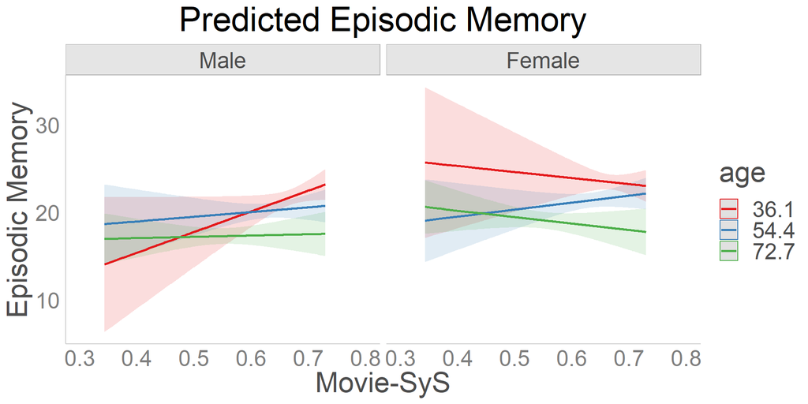

```r
# MOVIE
lm_model_M <- lm(Memory_700 ~ scale(age)*scale(Movie)*Sex + I(scale(age)^2)*scale(Movie)*Sex,
                 data = df_main_plot);

PRED = ggpredict(lm_model_M,terms=c('Movie [all]','age','Sex'))
plot(PRED) + labs(x="Movie-SyS", y='Episodic Memory', title='Predicted Episodic Memory') +
  theme(text = element_text(size=25)) + geom_line(size=1) + xlim(0.3,0.80) + theme(panel.grid.major = element_blank(), panel.grid.minor = element_blank(),                                                                                                                                                                               panel.background = element_blank(), axis.line = element_line(colour = "black")) +
  theme(plot.title = element_text(hjust = 0.5))  +  theme(axis.text.x = element_text(vjust = 2) + theme(axis.text.x=element_text(margin = margin(b=20))) )
```

```r
ggsave(file.path('./data_for_figures/Main',"Mov_FS_and_Memory_Interaction_Sex.png"), width = 35, height = 25, units = 'cm', dpi = 300);
```

# Model predicting SYS with IQ and Memory Reported in Supplementary

```r
df_Schafer_TEMP = df_Schafer
colnames(df_Schafer_TEMP)[4] = 'IQ'
colnames(df_Schafer_TEMP)[5] = 'M'
colnames(df_Schafer_TEMP)[6] = 'MSyS'
colnames(df_Schafer_TEMP)[7] = 'RSyS'
colnames(df_Schafer_TEMP)[8] = 'SSyS'


library(multcomp)

K_sub <- matrix(c(0,-1,0,0,0,1),1)

lm_model_R <- lm(scale(RSyS) ~ scale(M)+scale(ageQuad)+Sex+scale(IQ),
                 data = df_Schafer_TEMP);

summary(lm_model_R)
```

```
##
## Call:
## lm(formula = scale(RSyS) ~ scale(M) + scale(ageQuad) + Sex +
##     scale(IQ), data = df_Schafer_TEMP)
##
## Residuals:
##     Min      1Q  Median      3Q     Max
## -5.2382 -0.3743  0.0781  0.4881  1.9151
##
## Coefficients:
##                 Estimate Std. Error t value Pr(>|t|)
## (Intercept)     -0.01559    0.04432  -0.352 0.725091
## scale(M)         0.04005    0.03633   1.102 0.270694
## scale(ageQuad)1 -0.44428    0.04207 -10.561  < 2e-16 ***
## scale(ageQuad)2 -0.12080    0.03171  -3.809 0.000153 ***
## SexFemale        0.03124    0.06346   0.492 0.622741
## scale(IQ)        0.20149    0.04565   4.414  1.2e-05 ***
## ---
## Signif. codes:  0 '***' 0.001 '**' 0.01 '*' 0.05 '.' 0.1 ' ' 1
##
## Residual standard error: 0.7761 on 621 degrees of freedom
## Multiple R-squared:  0.4025, Adjusted R-squared:  0.3976
## F-statistic: 83.65 on 5 and 621 DF,  p-value: < 2.2e-16
```

```r
etasq(lm_model_R,anova=FALSE,partial = TRUE)
```

```
##                Partial eta^2
## scale(M)        0.0019533272
## scale(ageQuad)  0.1588581971
## Sex             0.0003899862
## scale(IQ)       0.0304181932
## Residuals                 NA
```

```r
T_test_Rest <- glht(lm_model_R,linfct=K_sub)
summary(T_test_Rest)
```

```
##
##   Simultaneous Tests for General Linear Hypotheses
##
## Fit: lm(formula = scale(RSyS) ~ scale(M) + scale(ageQuad) + Sex +
##     scale(IQ), data = df_Schafer_TEMP)
##
## Linear Hypotheses:
##        Estimate Std. Error t value Pr(>|t|)
## 1 == 0  0.16143    0.06788   2.378   0.0177 *
## ---
## Signif. codes:  0 '***' 0.001 '**' 0.01 '*' 0.05 '.' 0.1 ' ' 1
## (Adjusted p values reported -- single-step method)
```

```r
lm_model_M <- lm(scale(MSyS) ~ scale(M)+scale(ageQuad)+Sex+scale(IQ),
                 data = df_Schafer_TEMP);

summary(lm_model_M)
```

```
##
## Call:
## lm(formula = scale(MSyS) ~ scale(M) + scale(ageQuad) + Sex +
##     scale(IQ), data = df_Schafer_TEMP)
##
## Residuals:
##     Min      1Q  Median      3Q     Max
## -4.4768 -0.3479  0.0830  0.4514  1.7982
##
## Coefficients:
##                 Estimate Std. Error t value Pr(>|t|)
## (Intercept)     -0.04016    0.04122  -0.974    0.330
## scale(M)        -0.03702    0.03379  -1.096    0.274
## scale(ageQuad)1 -0.56221    0.03913 -14.368  < 2e-16 ***
## scale(ageQuad)2 -0.13330    0.02950  -4.519 7.43e-06 ***
## SexFemale        0.08045    0.05902   1.363    0.173
## scale(IQ)        0.17523    0.04246   4.127 4.17e-05 ***
## ---
## Signif. codes:  0 '***' 0.001 '**' 0.01 '*' 0.05 '.' 0.1 ' ' 1
##
## Residual standard error: 0.7219 on 621 degrees of freedom
## Multiple R-squared:  0.4831, Adjusted R-squared:  0.4789
## F-statistic: 116.1 on 5 and 621 DF,  p-value: < 2.2e-16
```

```r
etasq(lm_model_M,anova=FALSE,partial = TRUE)
```

```
##                Partial eta^2
## scale(M)         0.001929254
## scale(ageQuad)   0.255554603
## Sex              0.002982823
## scale(IQ)        0.026698234
## Residuals                 NA
```

```r
T_test_MOV <- glht(lm_model_M,linfct=K_sub)
summary(T_test_MOV)
```

```
##
##   Simultaneous Tests for General Linear Hypotheses
##
## Fit: lm(formula = scale(MSyS) ~ scale(M) + scale(ageQuad) + Sex +
##     scale(IQ), data = df_Schafer_TEMP)
##
## Linear Hypotheses:
##        Estimate Std. Error t value Pr(>|t|)
## 1 == 0  0.21226    0.06313   3.362 0.000821 ***
## ---
## Signif. codes:  0 '***' 0.001 '**' 0.01 '*' 0.05 '.' 0.1 ' ' 1
## (Adjusted p values reported -- single-step method)
```

```r
lm_model_S <- lm(scale(SSyS) ~ scale(M)+scale(ageQuad)+Sex+scale(IQ),
                 data = df_Schafer_TEMP);

summary(lm_model_S)
```

```
##
## Call:
## lm(formula = scale(SSyS) ~ scale(M) + scale(ageQuad) + Sex +
##     scale(IQ), data = df_Schafer_TEMP)
##
## Residuals:
##     Min      1Q  Median      3Q     Max
## -4.9546 -0.3231  0.0864  0.4151  1.6703
##
## Coefficients:
##                   Estimate Std. Error t value Pr(>|t|)
## (Intercept)     -0.0001209  0.0395434  -0.003    0.998
## scale(M)        -0.0053223  0.0324163  -0.164    0.870
## scale(ageQuad)1 -0.5811540  0.0375357 -15.483  < 2e-16 ***
## scale(ageQuad)2 -0.1248798  0.0282959  -4.413 1.20e-05 ***
## SexFemale        0.0002422  0.0566193   0.004    0.997
## scale(IQ)        0.1767070  0.0407290   4.339 1.67e-05 ***
## ---
## Signif. codes:  0 '***' 0.001 '**' 0.01 '*' 0.05 '.' 0.1 ' ' 1
##
## Residual standard error: 0.6925 on 621 degrees of freedom
## Multiple R-squared:  0.5243, Adjusted R-squared:  0.5205
## F-statistic: 136.9 on 5 and 621 DF,  p-value: < 2.2e-16
```

```r
etasq(lm_model_S,anova=FALSE,partial = TRUE)
```

```
##                Partial eta^2
## scale(M)        4.340680e-05
## scale(ageQuad)  2.830469e-01
## Sex             2.947062e-08
## scale(IQ)       2.941974e-02
## Residuals                 NA
```

```r
T_test_S <- glht(lm_model_S,linfct=K_sub)
summary(T_test_S)
```

```
##
##   Simultaneous Tests for General Linear Hypotheses
##
## Fit: lm(formula = scale(SSyS) ~ scale(M) + scale(ageQuad) + Sex +
##     scale(IQ), data = df_Schafer_TEMP)
##
## Linear Hypotheses:
##        Estimate Std. Error t value Pr(>|t|)
## 1 == 0  0.18203    0.06056   3.006  0.00276 **
## ---
## Signif. codes:  0 '***' 0.001 '**' 0.01 '*' 0.05 '.' 0.1 ' ' 1
## (Adjusted p values reported -- single-step method)
```

# Controlling for TIV and Education Reported in Supplementary

```r
# REST
lm_model_R <- lm(CattellPCA ~ scale(Rest_SyS)*scale(ageQuad)*SexC +scale(TIV) + scale(Education),
                 data = df_Schafer);

summary(lm_model_R)
```

```
##
## Call:
## lm(formula = CattellPCA ~ scale(Rest_SyS) * scale(ageQuad) *
##     SexC + scale(TIV) + scale(Education), data = df_Schafer)
##
## Residuals:
##     Min      1Q  Median      3Q     Max
## -7.0017 -1.4807  0.1146  1.5361  5.9453
##
## Coefficients:
##                                       Estimate Std. Error t value Pr(>|t|)
## (Intercept)                          16.014201   0.117761 135.989  < 2e-16 ***
## scale(Rest_SyS)                       0.609240   0.129591   4.701 3.20e-06 ***
## scale(ageQuad)1                      -1.655043   0.133126 -12.432  < 2e-16 ***
## scale(ageQuad)2                      -0.439788   0.111918  -3.930 9.48e-05 ***
## SexC                                 -0.161070   0.143548  -1.122   0.2623
## scale(TIV)                            0.347109   0.123493   2.811   0.0051 **
## scale(Education)                      0.838375   0.099089   8.461  < 2e-16 ***
## scale(Rest_SyS):scale(ageQuad)1      -0.223843   0.136972  -1.634   0.1027
## scale(Rest_SyS):scale(ageQuad)2      -0.008706   0.109622  -0.079   0.9367
## scale(Rest_SyS):SexC                 -0.036050   0.129041  -0.279   0.7801
## scale(ageQuad)1:SexC                  0.051517   0.131203   0.393   0.6947
## scale(ageQuad)2:SexC                 -0.134223   0.111680  -1.202   0.2299
## scale(Rest_SyS):scale(ageQuad)1:SexC -0.257385   0.136809  -1.881   0.0604 .
## scale(Rest_SyS):scale(ageQuad)2:SexC  0.057178   0.109444   0.522   0.6016
## ---
## Signif. codes:  0 '***' 0.001 '**' 0.01 '*' 0.05 '.' 0.1 ' ' 1
##
## Residual standard error: 2.25 on 612 degrees of freedom
##   (1 observation deleted due to missingness)
## Multiple R-squared:  0.5679, Adjusted R-squared:  0.5587
## F-statistic: 61.87 on 13 and 612 DF,  p-value: < 2.2e-16
```

```r
etasq(lm_model_R,anova=FALSE,partial = TRUE)
```

```
##                                     Partial eta^2
## scale(Rest_SyS)                      3.069967e-02
## scale(ageQuad)                       2.667414e-01
## SexC                                 1.350554e-05
## scale(TIV)                           1.274451e-02
## scale(Education)                     1.047201e-01
## scale(Rest_SyS):scale(ageQuad)       4.003057e-03
## scale(Rest_SyS):SexC                 2.630934e-03
## scale(ageQuad):SexC                  7.173254e-05
## scale(Rest_SyS):scale(ageQuad):SexC  5.908347e-03
## Residuals                                      NA
```

```r
# MOVIE
lm_model_M <- lm(CattellPCA ~ scale(Mov_SyS)*scale(ageQuad)*SexC +scale(TIV) + scale(Education),
                 data = df_Schafer);

summary(lm_model_M)
```

```
##
## Call:
## lm(formula = CattellPCA ~ scale(Mov_SyS) * scale(ageQuad) * SexC +
##     scale(TIV) + scale(Education), data = df_Schafer)
##
## Residuals:
##    Min     1Q Median     3Q    Max
## -7.076 -1.435  0.129  1.648  5.307
##
## Coefficients:
##                                      Estimate Std. Error t value Pr(>|t|)
## (Intercept)                         16.065130   0.131349 122.309  < 2e-16 ***
## scale(Mov_SyS)                       0.511008   0.143509   3.561 0.000398 ***
## scale(ageQuad)1                     -1.656168   0.149109 -11.107  < 2e-16 ***
## scale(ageQuad)2                     -0.400875   0.122902  -3.262 0.001169 **
## SexC                                 0.017402   0.156235   0.111 0.911348
## scale(TIV)                           0.380922   0.124143   3.068 0.002247 **
## scale(Education)                     0.863277   0.099354   8.689  < 2e-16 ***
## scale(Mov_SyS):scale(ageQuad)1      -0.133949   0.149357  -0.897 0.370158
## scale(Mov_SyS):scale(ageQuad)2       0.001152   0.111385   0.010 0.991749
## scale(Mov_SyS):SexC                 -0.167444   0.143291  -1.169 0.243037
## scale(ageQuad)1:SexC                -0.071333   0.147076  -0.485 0.627842
## scale(ageQuad)2:SexC                 0.007320   0.122427   0.060 0.952344
## scale(Mov_SyS):scale(ageQuad)1:SexC  0.040256   0.149577   0.269 0.787921
## scale(Mov_SyS):scale(ageQuad)2:SexC -0.052285   0.111020  -0.471 0.637846
## ---
## Signif. codes:  0 '***' 0.001 '**' 0.01 '*' 0.05 '.' 0.1 ' ' 1
##
## Residual standard error: 2.271 on 612 degrees of freedom
##   (1 observation deleted due to missingness)
## Multiple R-squared:   0.56,  Adjusted R-squared:  0.5506
## F-statistic: 59.91 on 13 and 612 DF,  p-value: < 2.2e-16
```

```r
etasq(lm_model_M,anova=FALSE,partial = TRUE)
```

```
##                                    Partial eta^2
## scale(Mov_SyS)                      2.128307e-02
## scale(ageQuad)                      2.300316e-01
## SexC                                2.414589e-06
## scale(TIV)                          1.515117e-02
## scale(Education)                    1.098134e-01
## scale(Mov_SyS):scale(ageQuad)       1.541793e-03
## scale(Mov_SyS):SexC                 2.385343e-03
## scale(ageQuad):SexC                 1.425078e-04
## scale(Mov_SyS):scale(ageQuad):SexC  3.807925e-04
## Residuals                                     NA
```

```r
# SMT
lm_model_S <- lm(CattellPCA ~ scale(SMT_SyS)*scale(ageQuad)*SexC +scale(TIV) + scale(Education),
                 data = df_Schafer);

summary(lm_model_S)
```

```
##
## Call:
## lm(formula = CattellPCA ~ scale(SMT_SyS) * scale(ageQuad) * SexC +
##     scale(TIV) + scale(Education), data = df_Schafer)
##
## Residuals:
##     Min      1Q  Median      3Q     Max
## -6.9535 -1.4676  0.1126  1.6748  5.4681
##
## Coefficients:
##                                     Estimate Std. Error t value Pr(>|t|)
## (Intercept)                         16.12433    0.14377 112.152  < 2e-16 ***
## scale(SMT_SyS)                       0.47308    0.15865   2.982  0.00298 **
## scale(ageQuad)1                     -1.72855    0.16423 -10.525  < 2e-16 ***
## scale(ageQuad)2                     -0.33178    0.13216  -2.511  0.01231 *
## SexC                                -0.05634    0.16755  -0.336  0.73678
## scale(TIV)                           0.38065    0.12452   3.057  0.00233 **
## scale(Education)                     0.82775    0.10036   8.248 9.91e-16 ***
## scale(SMT_SyS):scale(ageQuad)1      -0.01129    0.17035  -0.066  0.94718
## scale(SMT_SyS):scale(ageQuad)2      -0.11119    0.11555  -0.962  0.33633
## scale(SMT_SyS):SexC                 -0.16886    0.15805  -1.068  0.28576
## scale(ageQuad)1:SexC                -0.07400    0.16254  -0.455  0.64907
## scale(ageQuad)2:SexC                -0.09271    0.13224  -0.701  0.48351
## scale(SMT_SyS):scale(ageQuad)1:SexC -0.10795    0.17011  -0.635  0.52592
## scale(SMT_SyS):scale(ageQuad)2:SexC -0.01602    0.11487  -0.139  0.88910
## ---
## Signif. codes:  0 '***' 0.001 '**' 0.01 '*' 0.05 '.' 0.1 ' ' 1
##
## Residual standard error: 2.268 on 612 degrees of freedom
##   (1 observation deleted due to missingness)
## Multiple R-squared:  0.561,  Adjusted R-squared:  0.5517
## F-statistic: 60.16 on 13 and 612 DF,  p-value: < 2.2e-16
```

```r
etasq(lm_model_S,anova=FALSE,partial = TRUE)
```

```
##                                    Partial eta^2
## scale(SMT_SyS)                      2.135555e-02
## scale(ageQuad)                      2.151793e-01
## SexC                                8.036939e-05
## scale(TIV)                          1.503964e-02
## scale(Education)                    1.000303e-01
## scale(SMT_SyS):scale(ageQuad)       1.655013e-03
## scale(SMT_SyS):SexC                 4.670139e-03
## scale(ageQuad):SexC                 9.546461e-04
## scale(SMT_SyS):scale(ageQuad):SexC  1.016304e-03
## Residuals                                     NA
```

```r
# REST
lm_model_R <- lm(Memory_700 ~ scale(Rest_SyS)*scale(ageQuad)*SexC +scale(TIV) + scale(Education),
                 data = df_Schafer);

summary(lm_model_R)
```

```
##
## Call:
## lm(formula = Memory_700 ~ scale(Rest_SyS) * scale(ageQuad) *
##     SexC + scale(TIV) + scale(Education), data = df_Schafer)
##
## Residuals:
##      Min       1Q   Median       3Q      Max
## -19.2755  -3.1534   0.3681   3.2322  16.8037
##
## Coefficients:
##                                      Estimate Std. Error t value Pr(>|t|)
## (Intercept)                          20.37265    0.26235  77.654  < 2e-16 ***
## scale(Rest_SyS)                       0.70474    0.28870   2.441  0.01493 *
## scale(ageQuad)1                      -1.38055    0.29658  -4.655 3.98e-06 ***
## scale(ageQuad)2                      -0.11246    0.24933  -0.451  0.65213
## SexC                                  0.97833    0.31980   3.059  0.00232 **
## scale(TIV)                            0.21914    0.27512   0.797  0.42603
## scale(Education)                      1.12649    0.22075   5.103 4.47e-07 ***
## scale(Rest_SyS):scale(ageQuad)1      -0.28808    0.30515  -0.944  0.34551
## scale(Rest_SyS):scale(ageQuad)2      -0.04717    0.24422  -0.193  0.84691
## scale(Rest_SyS):SexC                 -0.01283    0.28748  -0.045  0.96441
## scale(ageQuad)1:SexC                 -0.09827    0.29230  -0.336  0.73683
## scale(ageQuad)2:SexC                  0.24842    0.24880   0.998  0.31845
## scale(Rest_SyS):scale(ageQuad)1:SexC  0.21039    0.30478   0.690  0.49028
## scale(Rest_SyS):scale(ageQuad)2:SexC -0.24405    0.24382  -1.001  0.31725
## ---
## Signif. codes:  0 '***' 0.001 '**' 0.01 '*' 0.05 '.' 0.1 ' ' 1
##
## Residual standard error: 5.013 on 612 degrees of freedom
##   (1 observation deleted due to missingness)
## Multiple R-squared:  0.2159, Adjusted R-squared:  0.1992
## F-statistic: 12.96 on 13 and 612 DF,  p-value: < 2.2e-16
```

```r
etasq(lm_model_R,anova=FALSE,partial = TRUE)
```

```
##                                     Partial eta^2
## scale(Rest_SyS)                      8.316006e-03
## scale(ageQuad)                       4.755995e-02
## SexC                                 1.699403e-02
## scale(TIV)                           1.035645e-03
## scale(Education)                     4.081277e-02
## scale(Rest_SyS):scale(ageQuad)       2.451141e-03
## scale(Rest_SyS):SexC                 9.765293e-05
## scale(ageQuad):SexC                  9.270886e-04
## scale(Rest_SyS):scale(ageQuad):SexC  1.771131e-03
## Residuals                                      NA
```

```r
# MOVIE
lm_model_M <- lm(Memory_700 ~ scale(Mov_SyS)*scale(ageQuad)*SexC +scale(TIV) + scale(Education),
                 data = df_Schafer);

summary(lm_model_M)
```

```
##
## Call:
## lm(formula = Memory_700 ~ scale(Mov_SyS) * scale(ageQuad) * SexC +
##     scale(TIV) + scale(Education), data = df_Schafer)
##
## Residuals:
##      Min       1Q   Median       3Q      Max
## -18.8207  -3.1660   0.4959   3.2835  17.3578
##
## Coefficients:
##                                     Estimate Std. Error t value Pr(>|t|)
## (Intercept)                         20.30548    0.29022  69.966  < 2e-16 ***
## scale(Mov_SyS)                       0.15557    0.31709   0.491 0.623869
## scale(ageQuad)1                     -1.70459    0.32946  -5.174 3.11e-07 ***
## scale(ageQuad)2                     -0.24223    0.27156  -0.892 0.372744
## SexC                                 1.16012    0.34521   3.361 0.000826 ***
## scale(TIV)                           0.24962    0.27430   0.910 0.363158
## scale(Education)                     1.16792    0.21953   5.320 1.46e-07 ***
## scale(Mov_SyS):scale(ageQuad)1      -0.36513    0.33001  -1.106 0.268982
## scale(Mov_SyS):scale(ageQuad)2      -0.03963    0.24611  -0.161 0.872132
## scale(Mov_SyS):SexC                 -0.38600    0.31661  -1.219 0.223247
## scale(ageQuad)1:SexC                -0.47475    0.32497  -1.461 0.144557
## scale(ageQuad)2:SexC                 0.37080    0.27051   1.371 0.170956
## scale(Mov_SyS):scale(ageQuad)1:SexC  0.48518    0.33050   1.468 0.142605
## scale(Mov_SyS):scale(ageQuad)2:SexC -0.46748    0.24530  -1.906 0.057155 .
## ---
## Signif. codes:  0 '***' 0.001 '**' 0.01 '*' 0.05 '.' 0.1 ' ' 1
##
## Residual standard error: 5.017 on 612 degrees of freedom
##   (1 observation deleted due to missingness)
## Multiple R-squared:  0.2146, Adjusted R-squared:  0.1979
## F-statistic: 12.86 on 13 and 612 DF,  p-value: < 2.2e-16
```

```r
etasq(lm_model_M,anova=FALSE,partial = TRUE)
```

```
##                                    Partial eta^2
## scale(Mov_SyS)                      4.345349e-06
## scale(ageQuad)                      6.023676e-02
## SexC                                1.744268e-02
## scale(TIV)                          1.351405e-03
## scale(Education)                    4.420421e-02
## scale(Mov_SyS):scale(ageQuad)       3.129536e-03
## scale(Mov_SyS):SexC                 7.042961e-04
## scale(ageQuad):SexC                 8.393770e-04
## scale(Mov_SyS):scale(ageQuad):SexC  7.030009e-03
## Residuals                                     NA
```

```r
# SMT
lm_model_S <- lm(Memory_700 ~ scale(SMT_SyS)*scale(ageQuad)*SexC +scale(TIV) + scale(Education),
                 data = df_Schafer);

summary(lm_model_S)
```

```
##
## Call:
## lm(formula = Memory_700 ~ scale(SMT_SyS) * scale(ageQuad) * SexC +
##     scale(TIV) + scale(Education), data = df_Schafer)
##
## Residuals:
##      Min       1Q   Median       3Q      Max
## -19.0170  -3.2464   0.3143   3.3012  17.1207
##
## Coefficients:
##                                     Estimate Std. Error t value Pr(>|t|)
## (Intercept)                         20.25963    0.31835  63.640  < 2e-16 ***
## scale(SMT_SyS)                       0.32322    0.35130   0.920  0.35790
## scale(ageQuad)1                     -1.57278    0.36365  -4.325 1.78e-05 ***
## scale(ageQuad)2                     -0.26164    0.29263  -0.894  0.37162
## SexC                                 1.12568    0.37100   3.034  0.00251 **
## scale(TIV)                           0.22625    0.27572   0.821  0.41221
## scale(Education)                     1.16822    0.22223   5.257 2.03e-07 ***
## scale(SMT_SyS):scale(ageQuad)1      -0.41436    0.37719  -1.099  0.27240
## scale(SMT_SyS):scale(ageQuad)2      -0.05331    0.25587  -0.208  0.83503
## scale(SMT_SyS):SexC                 -0.31357    0.34996  -0.896  0.37058
## scale(ageQuad)1:SexC                -0.39310    0.35991  -1.092  0.27517
## scale(ageQuad)2:SexC                 0.34651    0.29282   1.183  0.23713
## scale(SMT_SyS):scale(ageQuad)1:SexC  0.39194    0.37666   1.041  0.29849
## scale(SMT_SyS):scale(ageQuad)2:SexC -0.36956    0.25436  -1.453  0.14677
## ---
## Signif. codes:  0 '***' 0.001 '**' 0.01 '*' 0.05 '.' 0.1 ' ' 1
##
## Residual standard error: 5.022 on 612 degrees of freedom
##   (1 observation deleted due to missingness)
## Multiple R-squared:  0.2131, Adjusted R-squared:  0.1964
## F-statistic: 12.75 on 13 and 612 DF,  p-value: < 2.2e-16
```

```r
etasq(lm_model_S,anova=FALSE,partial = TRUE)
```

```
##                                    Partial eta^2
## scale(SMT_SyS)                      0.0008232395
## scale(ageQuad)                      0.0484516368
## SexC                                0.0177898665
## scale(TIV)                          0.0010989926
## scale(Education)                    0.0432038965
## scale(SMT_SyS):scale(ageQuad)       0.0040277537
## scale(SMT_SyS):SexC                 0.0002674901
## scale(ageQuad):SexC                 0.0007368103
## scale(SMT_SyS):scale(ageQuad):SexC  0.0037558097
## Residuals                                     NA
```

**4) NOW focusing on Midlife Activities**

```r
df_LEQ = read.csv('Main_SyS_LEQ_Subscores.csv')
colnames(df_LEQ)[colnames(df_LEQ) == 'CattellPCA'] <- 'Cattell'
colnames(df_LEQ)[colnames(df_LEQ) == 'age'] <- 'Age'
head(df_LEQ)
```

```
##       CCID Age Sex  Cattell Memory_700   Mov_SyS  Rest_SyS   SMT_SyS YS
## 1 CC510208  66   2 17.38299   22.90905 0.6385885 0.6446094 0.6629277 10
## 2 CC510220  66   1 17.72735   23.09673 0.5430167 0.5789093 0.5771224 10
## 3 CC510226  67   1 12.17715   18.10481 0.6484342 0.6773990 0.6682158  5
## 4 CC510237  66   1 16.59281   28.45509 0.5810524 0.6489869 0.6435950  7
## 5 CC510304  66   2 16.61167   14.68979 0.6167530 0.6418694 0.5599751  0
## 6 CC510392  67   1 14.36752   12.12483 0.6154680 0.6606052 0.6749547  0
##         YA       MS       MA       LS       LA IQ_sub1 IQ_sub2 IQ_sub3 IQ_sub4
## 1 5.806452 8.404255 6.666667 5.161290 4.000000      11       9      10       4
## 2 6.451613 9.361702 8.333333 5.483871 5.333333       9      10      10       6
## 3 6.774194 9.574468 7.000000 7.741935 4.333333       9       3       8       4
## 4 4.838710 9.042553 4.333333 4.516129 4.333333      11       8       8       6
## 5 0.000000 6.170213 9.000000 7.419355 5.666667       8       8      10       7
## 6 4.838710 6.382979 5.000000 4.838710 4.000000      10       6       6       7
##   Mem_subc1 Mem_subc2 Mem_subc3
## 1        16        15         9
## 2        17        14        10
## 3        12        12        10
## 4        19        20         9
## 5        11         8        10
## 6         6        10         8
```

```r
#report covariances/correlations in LEQ
#cov(dplyr::select(df_LEQ,Cattell,YS:LA,Age), y=NULL)
corr.test(data.frame(dplyr::select(df_LEQ,Cattell,YS:LA,Age)))
```

```
## Call:corr.test(x = data.frame(dplyr::select(df_LEQ, Cattell, YS:LA,
##     Age)))
## Correlation matrix
##         Cattell    YS    YA    MS    MA   LS    LA   Age
## Cattell    1.00  0.43  0.33  0.36  0.40 0.19  0.26 -0.33
## YS         0.43  1.00  0.46  0.47  0.28 0.16  0.34 -0.12
## YA         0.33  0.46  1.00  0.21  0.55 0.30  0.54 -0.07
## MS         0.36  0.47  0.21  1.00  0.18 0.16  0.19 -0.25
## MA         0.40  0.28  0.55  0.18  1.00 0.25  0.58 -0.04
## LS         0.19  0.16  0.30  0.16  0.25 1.00  0.32  0.06
## LA         0.26  0.34  0.54  0.19  0.58 0.32  1.00 -0.08
## Age       -0.33 -0.12 -0.07 -0.25 -0.04 0.06 -0.08  1.00
## Sample Size
## [1] 192
## Probability values (Entries above the diagonal are adjusted for multiple tests.)
##         Cattell   YS   YA   MS   MA   LS   LA  Age
## Cattell    0.00 0.00 0.00 0.00 0.00 0.09 0.00 0.00
## YS         0.00 0.00 0.00 0.00 0.00 0.18 0.00 0.50
## YA         0.00 0.00 0.00 0.03 0.00 0.00 0.00 1.00
## MS         0.00 0.00 0.00 0.00 0.09 0.18 0.09 0.01
## MA         0.00 0.00 0.00 0.01 0.00 0.01 0.00 1.00
## LS         0.01 0.03 0.00 0.03 0.00 0.00 0.00 1.00
## LA         0.00 0.00 0.00 0.01 0.00 0.00 0.00 0.98
## Age        0.00 0.10 0.37 0.00 0.56 0.39 0.25 0.00
##
##  To see confidence intervals of the correlations, print with the short=FALSE option
```

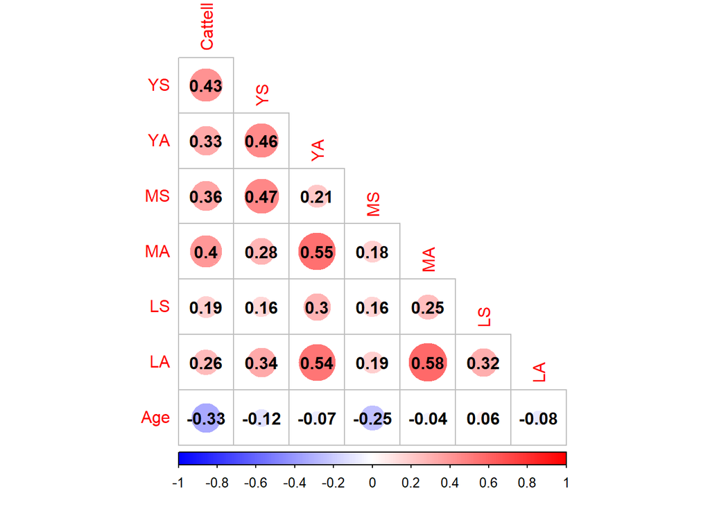

```r
corrplot(cor(data.frame(dplyr::select(df_LEQ,Cattell,YS:LA,Age))),type="lower",diag=FALSE,  addCoef.col = 'black', col=colorRampPalette(c("blue","white","red"))(200) )
```

Grab individuals for whom I have SyS data

```r
df_temp = df_LEQ
df_temp = df_temp[complete.cases(df_temp$Rest_SyS),]
df_temp = df_temp[complete.cases(df_temp$Mov_SyS),]
df_temp = df_temp[complete.cases(df_temp$SMT_SyS),]
sprintf('Subjects wtih Complete data = %1.0f',nrow(df_temp))
```

```
## [1] "Subjects wtih Complete data = 192"
```

```r
df_temp$ageQuad <- poly(df_temp$Age,2) #1st linear, 2nd quad
df_temp$agepoly_1  = df_temp$ageQuad[,1]
df_temp$agepoly_2 = df_temp$ageQuad[,2]

df_temp$Sex = factor(df_temp$Sex)
levels(df_temp$Sex) <- c('Male','Female')

df_temp %>%
     group_by(Sex) %>%
     summarise(gender_count=n())
```

```
## # A tibble: 2 × 2
##   Sex    gender_count
##   <fct>         <int>
## 1 Male            104
## 2 Female           88
```

```r
df_temp[df_temp$Sex == 'Male','SexC'] = -1
df_temp[df_temp$Sex == 'Female','SexC'] = 1
```

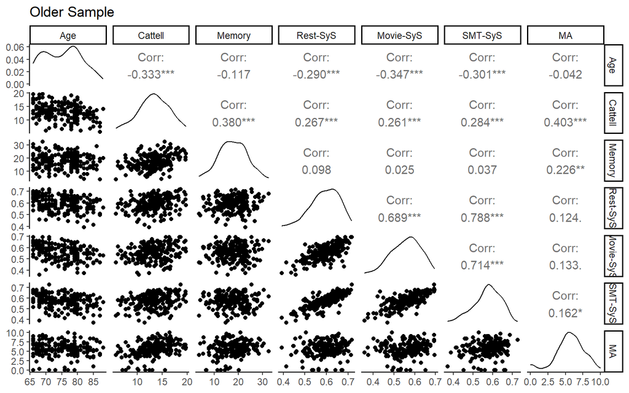

```r
ggPairData = with(df_temp, data.frame(Age,Cattell, Memory_700,Rest_SyS,Mov_SyS,SMT_SyS,MA))
colnames(ggPairData) <- c('Age','Cattell','Memory','Rest-SyS','Movie-SyS','SMT-SyS','MA')
ggPairData = ggPairData[complete.cases(ggPairData), ]
ggpairs(ggPairData,
        lower = list(continuous = "points", combo = "dot_no_facet"),progress=FALSE,title='Older Sample') + theme_classic()
```

> Run pre-registered models see https://osf.io/bq3a7/wiki/home/

**5.a) Mid-life activities (from the LEQ retrospective questionnaire) will positively predict SyS (in multiple linear regression, adjusting for age and sex). - Table 4** *Predict SyS from MA in older adults controlling for Age and Sex*

```r
# REST
prepreg_1_R <- lm(Rest_SyS ~ scale(MA) + scale(Age)  + SexC, data = df_temp)

summary(prepreg_1_R)
```

```
##
## Call:
## lm(formula = Rest_SyS ~ scale(MA) + scale(Age) + SexC, data = df_temp)
##
## Residuals:
##       Min        1Q    Median        3Q       Max
## -0.180096 -0.039673  0.003496  0.047568  0.118499
##
## Coefficients:
##              Estimate Std. Error t value Pr(>|t|)
## (Intercept)  0.593861   0.004472 132.806  < 2e-16 ***
## scale(MA)    0.007393   0.004518   1.636    0.103
## scale(Age)  -0.018262   0.004486  -4.071  6.9e-05 ***
## SexC        -0.001335   0.004531  -0.295    0.769
## ---
## Signif. codes:  0 '***' 0.001 '**' 0.01 '*' 0.05 '.' 0.1 ' ' 1
##
## Residual standard error: 0.06174 on 188 degrees of freedom
## Multiple R-squared:  0.09679,    Adjusted R-squared:  0.08238
## F-statistic: 6.716 on 3 and 188 DF,  p-value: 0.0002499
```

```r
etasq(prepreg_1_R)
```

```
##            Partial eta^2
## scale(MA)   0.0140398336
## scale(Age)  0.0810048846
## SexC        0.0004617147
## Residuals             NA
```

```r
# Movie
prepreg_1_M <- lm(Mov_SyS ~ scale(MA) + scale(Age)  + SexC, data =df_temp)

summary(prepreg_1_M)
```

```
##
## Call:
## lm(formula = Mov_SyS ~ scale(MA) + scale(Age) + SexC, data = df_temp)
##
## Residuals:
##      Min       1Q   Median       3Q      Max
## -0.22326 -0.03842  0.01118  0.05010  0.11806
##
## Coefficients:
##               Estimate Std. Error t value Pr(>|t|)
## (Intercept)  0.5577607  0.0047689 116.957  < 2e-16 ***
## scale(MA)    0.0084502  0.0048185   1.754   0.0811 .
## scale(Age)  -0.0239242  0.0047843  -5.001 1.31e-06 ***
## SexC        -0.0009107  0.0048320  -0.188   0.8507
## ---
## Signif. codes:  0 '***' 0.001 '**' 0.01 '*' 0.05 '.' 0.1 ' ' 1
##
## Residual standard error: 0.06584 on 188 degrees of freedom
## Multiple R-squared:  0.1344, Adjusted R-squared:  0.1206
## F-statistic:  9.73 on 3 and 188 DF,  p-value: 5.331e-06
```

```r
etasq(prepreg_1_M)
```

```
##            Partial eta^2
## scale(MA)   0.0160950515
## scale(Age)  0.1173937750
## SexC        0.0001889088
## Residuals             NA
```

```r
# SMT
prepreg_1_SMT <- lm(SMT_SyS ~ scale(MA) + scale(Age) + SexC, data =df_temp)

summary(prepreg_1_SMT)
```

```
##
## Call:
## lm(formula = SMT_SyS ~ scale(MA) + scale(Age) + SexC, data = df_temp)
##
## Residuals:
##       Min        1Q    Median        3Q       Max
## -0.203956 -0.033734  0.004082  0.050251  0.124971
##
## Coefficients:
##              Estimate Std. Error t value Pr(>|t|)
## (Intercept)  0.572441   0.004637 123.440  < 2e-16 ***
## scale(MA)    0.010292   0.004686   2.197   0.0293 *
## scale(Age)  -0.019737   0.004652  -4.242 3.47e-05 ***
## SexC        -0.001508   0.004699  -0.321   0.7486
## ---
## Signif. codes:  0 '***' 0.001 '**' 0.01 '*' 0.05 '.' 0.1 ' ' 1
##
## Residual standard error: 0.06403 on 188 degrees of freedom
## Multiple R-squared:  0.1131, Adjusted R-squared:  0.09899
## F-statistic: 7.995 on 3 and 188 DF,  p-value: 4.815e-05
```

```r
etasq(prepreg_1_SMT)
```

```
##            Partial eta^2
## scale(MA)   0.0250220167
## scale(Age)  0.0873700527
## SexC        0.0005475464
## Residuals             NA
```

**5.b) This positive relationship will remain even when adjusting for the other 5 LEQ scores (one of which includes education)** *There was no positive association to begin with, but for completeness*

```r
# REST
prepreg_2_R <- lm(Rest_SyS ~ scale(Age)+SexC + scale(MA) +scale(YS)+scale(YA)+scale(MS)+scale(LS)+scale(LA), data = df_temp)
summary(prepreg_2_R)
```

```
##
## Call:
## lm(formula = Rest_SyS ~ scale(Age) + SexC + scale(MA) + scale(YS) +
##     scale(YA) + scale(MS) + scale(LS) + scale(LA), data = df_temp)
##
## Residuals:
##       Min        1Q    Median        3Q       Max
## -0.184955 -0.041005  0.004222  0.047077  0.122257
##
## Coefficients:
##               Estimate Std. Error t value Pr(>|t|)
## (Intercept)  0.5939145  0.0044670 132.955  < 2e-16 ***
## scale(Age)  -0.0168465  0.0046427  -3.629  0.00037 ***
## SexC        -0.0006888  0.0050153  -0.137  0.89092
## scale(MA)    0.0006921  0.0058815   0.118  0.90646
## scale(YS)    0.0006427  0.0056489   0.114  0.90955
## scale(YA)    0.0054258  0.0061285   0.885  0.37713
## scale(MS)    0.0058462  0.0054404   1.075  0.28397
## scale(LS)    0.0047463  0.0049368   0.961  0.33762
## scale(LA)    0.0020887  0.0059125   0.353  0.72429
## ---
## Signif. codes:  0 '***' 0.001 '**' 0.01 '*' 0.05 '.' 0.1 ' ' 1
##
## Residual standard error: 0.06163 on 183 degrees of freedom
## Multiple R-squared:  0.1241, Adjusted R-squared:  0.08577
## F-statistic:  3.24 on 8 and 183 DF,  p-value: 0.001795
```

```r
# Movie
prepreg_2_M <- lm(Mov_SyS ~ scale(Age)+SexC + scale(MA) +scale(YS)+scale(YA)+scale(MS)+scale(LS)+scale(LA), data = df_temp)
summary(prepreg_2_M)
```

```
##
## Call:
## lm(formula = Mov_SyS ~ scale(Age) + SexC + scale(MA) + scale(YS) +
##     scale(YA) + scale(MS) + scale(LS) + scale(LA), data = df_temp)
##
## Residuals:
##      Min       1Q   Median       3Q      Max
## -0.21716 -0.04059  0.01206  0.04823  0.11657
##
## Coefficients:
##               Estimate Std. Error t value Pr(>|t|)
## (Intercept)  0.5579036  0.0048199 115.750  < 2e-16 ***
## scale(Age)  -0.0226374  0.0050095  -4.519 1.11e-05 ***
## SexC         0.0008038  0.0054115   0.149    0.882
## scale(MA)    0.0059809  0.0063461   0.942    0.347
## scale(YS)    0.0012709  0.0060951   0.209    0.835
## scale(YA)    0.0016223  0.0066126   0.245    0.806
## scale(MS)    0.0050067  0.0058701   0.853    0.395
## scale(LS)   -0.0001618  0.0053267  -0.030    0.976
## scale(LA)    0.0002515  0.0063795   0.039    0.969
## ---
## Signif. codes:  0 '***' 0.001 '**' 0.01 '*' 0.05 '.' 0.1 ' ' 1
##
## Residual standard error: 0.06649 on 183 degrees of freedom
## Multiple R-squared:  0.1407, Adjusted R-squared:  0.1032
## F-statistic: 3.746 on 8 and 183 DF,  p-value: 0.0004371
```

```r
# SMT
prepreg_2_S <- lm(SMT_SyS ~ scale(Age)+SexC + scale(MA) +scale(YS)+scale(YA)+scale(MS)+scale(LS)+scale(LA), data = df_temp)
summary(prepreg_2_S)
```

```
##
## Call:
## lm(formula = SMT_SyS ~ scale(Age) + SexC + scale(MA) + scale(YS) +
##     scale(YA) + scale(MS) + scale(LS) + scale(LA), data = df_temp)
##
## Residuals:
##       Min        1Q    Median        3Q       Max
## -0.183100 -0.037440  0.005758  0.050684  0.120534
##
## Coefficients:
##              Estimate Std. Error t value Pr(>|t|)
## (Intercept)  0.572469   0.004588 124.766  < 2e-16 ***
## scale(Age)  -0.018209   0.004769  -3.818 0.000184 ***
## SexC        -0.001170   0.005152  -0.227 0.820552
## scale(MA)    0.001080   0.006041   0.179 0.858255
## scale(YS)    0.001459   0.005802   0.251 0.801723
## scale(YA)    0.005891   0.006295   0.936 0.350615
## scale(MS)    0.005947   0.005588   1.064 0.288662
## scale(LS)    0.007313   0.005071   1.442 0.150947
## scale(LA)    0.004513   0.006073   0.743 0.458379
## ---
## Signif. codes:  0 '***' 0.001 '**' 0.01 '*' 0.05 '.' 0.1 ' ' 1
##
## Residual standard error: 0.0633 on 183 degrees of freedom
## Multiple R-squared:  0.1563, Adjusted R-squared:  0.1194
## F-statistic: 4.237 on 8 and 183 DF,  p-value: 0.0001099
```

**6) SyS should mediate the effect of mid-life activities on Cognition.** *(5.a) is not true but doing it for completeness* Does SyS mediate effect of MA on Fluid Intelligence, older sample - Table 5

```r
# REST
model_Fluid_MA_mediated_by_SYS_R <- '

# direct effect of MA
Cattell ~ c * MA +Age +SexC
# mediator SyS
Rest_SyS ~ a*MA
Cattell ~ b*Rest_SyS
## indirect effect (a*b)
ab := a*b
# total effect
total := c + (a*b)
'

fit_model_Fluid_MA_mediated_by_SyS_R <- sem(model_Fluid_MA_mediated_by_SYS_R, data = df_temp,bootstrap=5000)

parameterEstimates(fit_model_Fluid_MA_mediated_by_SyS_R, ci=TRUE,level=0.95,boot.ci.type="perc")
```

```
##         lhs op      rhs label    est    se      z pvalue ci.lower ci.upper
## 1   Cattell  ~       MA     c  0.596 0.093  6.389  0.000    0.413    0.779
## 2   Cattell  ~      Age       -0.138 0.031 -4.396  0.000   -0.200   -0.077
## 3   Cattell  ~     SexC       -0.412 0.187 -2.206  0.027   -0.778   -0.046
## 4  Rest_SyS  ~       MA     a  0.004 0.002  1.726  0.084   -0.001    0.008
## 5   Cattell  ~ Rest_SyS     b  6.484 2.877  2.254  0.024    0.845   12.122
## 6   Cattell ~~  Cattell        6.467 0.660  9.798  0.000    5.173    7.760
## 7  Rest_SyS ~~ Rest_SyS        0.004 0.000  9.798  0.000    0.003    0.005
## 8        MA ~~       MA        4.020 0.000     NA     NA    4.020    4.020
## 9        MA ~~      Age       -0.491 0.000     NA     NA   -0.491   -0.491
## 10       MA ~~     SexC        0.280 0.000     NA     NA    0.280    0.280
## 11      Age ~~      Age       34.381 0.000     NA     NA   34.381   34.381
## 12      Age ~~     SexC        0.435 0.000     NA     NA    0.435    0.435
## 13     SexC ~~     SexC        0.993 0.000     NA     NA    0.993    0.993
## 14       ab :=      a*b    ab  0.026 0.019  1.371  0.171   -0.011    0.062
## 15    total :=  c+(a*b) total  0.622 0.094  6.630  0.000    0.438    0.805
```

```r
summary(fit_model_Fluid_MA_mediated_by_SyS_R, fit.measures=TRUE,rsquare=TRUE)
```

```
## lavaan 0.6.15 ended normally after 1 iteration
##
##   Estimator                                         ML
##   Optimization method                           NLMINB
##   Number of model parameters                         7
##
##   Number of observations                           192
##
## Model Test User Model:
##
##   Test statistic                                16.588
##   Degrees of freedom                                 2
##   P-value (Chi-square)                           0.000
##
## Model Test Baseline Model:
##
##   Test statistic                                87.520
##   Degrees of freedom                                 7
##   P-value                                        0.000
##
## User Model versus Baseline Model:
##
##   Comparative Fit Index (CFI)                    0.819
##   Tucker-Lewis Index (TLI)                       0.366
##
## Loglikelihood and Information Criteria:
##
##   Loglikelihood user model (H0)               -195.659
##   Loglikelihood unrestricted model (H1)       -187.365
##
##   Akaike (AIC)                                 405.318
##   Bayesian (BIC)                               428.121
##   Sample-size adjusted Bayesian (SABIC)        405.947
##
## Root Mean Square Error of Approximation:
##
##   RMSEA                                          0.195
##   90 Percent confidence interval - lower         0.115
##   90 Percent confidence interval - upper         0.286
##   P-value H_0: RMSEA <= 0.050                    0.002
```

[output cut: 22 more lines]

```
##
## Variances:
##                    Estimate  Std.Err  z-value  P(>|z|)
##    .Cattell           6.467    0.660    9.798    0.000
##    .Rest_SyS          0.004    0.000    9.798    0.000
##
## R-Square:
##                    Estimate
##     Cattell           0.282
##     Rest_SyS          0.015
##
## Defined Parameters:
##                    Estimate  Std.Err  z-value  P(>|z|)
##     ab                0.026    0.019    1.371    0.171
##     total             0.622    0.094    6.630    0.000
```

```r
library(lavaanPlot)
labels_mediate <- list(Rest_SyS='Rest-SyS',Cattell='Fluid Intelligence',SexC='Sex')

Plot_lavan = lavaanPlot(model = fit_model_Fluid_MA_mediated_by_SyS_R,labels = labels_mediate,  coefs=TRUE,stand=TRUE,sig=0.05)
lavaanPlot(model = fit_model_Fluid_MA_mediated_by_SyS_R,labels =labels_mediate,  coefs=TRUE,stand=TRUE,sig=0.05)
```

[interactive chart not shown]

```r
save_png(Plot_lavan, file.path("./data_for_figures/Main/Mediation_Plot_REST.png"))


## MOVIE
model_Fluid_MA_mediated_by_SYS_M <- '

# direct effect of MA
Cattell ~ c * MA +Age + SexC
# mediator SyS
Mov_SyS ~ a*MA
Cattell ~ b*Mov_SyS
## indirect effect (a*b)
ab := a*b
# total effect
total := c + (a*b)
'

fit_model_Fluid_MA_mediated_by_SyS_M <- sem(model_Fluid_MA_mediated_by_SYS_M, data = df_temp,bootstrap=5000)

parameterEstimates(fit_model_Fluid_MA_mediated_by_SyS_M, ci=TRUE,level=0.95,boot.ci.type="perc")
```

```
##        lhs op     rhs label    est    se      z pvalue ci.lower ci.upper
## 1  Cattell  ~      MA     c  0.599 0.094  6.391  0.000    0.416    0.783
## 2  Cattell  ~     Age       -0.139 0.032 -4.388  0.000   -0.200   -0.077
## 3  Cattell  ~    SexC       -0.416 0.187 -2.219  0.026   -0.783   -0.049
## 4  Mov_SyS  ~      MA     a  0.005 0.002  1.856  0.063    0.000    0.010
## 5  Cattell  ~ Mov_SyS     b  4.865 2.656  1.832  0.067   -0.340   10.070
## 6  Cattell ~~ Cattell        6.523 0.666  9.798  0.000    5.218    7.828
## 7  Mov_SyS ~~ Mov_SyS        0.005 0.000  9.798  0.000    0.004    0.006
## 8       MA ~~      MA        4.020 0.000     NA     NA    4.020    4.020
## 9       MA ~~     Age       -0.491 0.000     NA     NA   -0.491   -0.491
## 10      MA ~~    SexC        0.280 0.000     NA     NA    0.280    0.280
## 11     Age ~~     Age       34.381 0.000     NA     NA   34.381   34.381
## 12     Age ~~    SexC        0.435 0.000     NA     NA    0.435    0.435
## 13    SexC ~~    SexC        0.993 0.000     NA     NA    0.993    0.993
## 14      ab :=     a*b    ab  0.023 0.017  1.304  0.192   -0.011    0.056
## 15   total := c+(a*b) total  0.622 0.094  6.633  0.000    0.438    0.806
```

```r
summary(fit_model_Fluid_MA_mediated_by_SyS_M, fit.measures=TRUE,rsquare=TRUE)
```

```
## lavaan 0.6.15 ended normally after 2 iterations
##
##   Estimator                                         ML
##   Optimization method                           NLMINB
##   Number of model parameters                         7
##
##   Number of observations                           192
##
## Model Test User Model:
##
##   Test statistic                                24.297
##   Degrees of freedom                                 2
##   P-value (Chi-square)                           0.000
##
## Model Test Baseline Model:
##
##   Test statistic                                94.018
##   Degrees of freedom                                 7
##   P-value                                        0.000
##
## User Model versus Baseline Model:
##
##   Comparative Fit Index (CFI)                    0.744
##   Tucker-Lewis Index (TLI)                       0.103
##
## Loglikelihood and Information Criteria:
##
##   Loglikelihood user model (H0)               -212.706
##   Loglikelihood unrestricted model (H1)       -200.558
##
##   Akaike (AIC)                                 439.412
##   Bayesian (BIC)                               462.214
##   Sample-size adjusted Bayesian (SABIC)        440.041
##
## Root Mean Square Error of Approximation:
##
##   RMSEA                                          0.241
##   90 Percent confidence interval - lower         0.161
##   90 Percent confidence interval - upper         0.331
##   P-value H_0: RMSEA <= 0.050                    0.000
```

[output cut: 22 more lines]

```
##
## Variances:
##                    Estimate  Std.Err  z-value  P(>|z|)
##    .Cattell           6.523    0.666    9.798    0.000
##    .Mov_SyS           0.005    0.000    9.798    0.000
##
## R-Square:
##                    Estimate
##     Cattell           0.276
##     Mov_SyS           0.018
##
## Defined Parameters:
##                    Estimate  Std.Err  z-value  P(>|z|)
##     ab                0.023    0.017    1.304    0.192
##     total             0.622    0.094    6.633    0.000
```

```r
labels_mediate <- list(Mov_SyS='Movie-SyS',Cattell='Fluid Intelligence',SexC='Sex')

Plot_lavan = lavaanPlot(model = fit_model_Fluid_MA_mediated_by_SyS_M,labels =labels_mediate,  coefs=TRUE,stand=TRUE,sig=0.05)
lavaanPlot(model = fit_model_Fluid_MA_mediated_by_SyS_M,labels =labels_mediate,  coefs=TRUE,stand=TRUE,sig=0.05)
```

[interactive chart not shown]

```r
save_png(Plot_lavan, file.path("./data_for_figures/Main/Mediation_Plot_Movie.png"))



## SMT
model_Fluid_MA_mediated_by_SyS_S <- '
# direct effect of MA
Cattell ~ c * MA +Age + SexC
# mediator SyS
SMT_SyS ~ a*MA
Cattell ~ b*SMT_SyS
## indirect effect (a*b)
ab := a*b
# total effect
total := c + (a*b)
'

fit_model_Fluid_MA_mediated_by_SyS_S <- sem(model_Fluid_MA_mediated_by_SyS_S, data = df_temp,bootstrap=5000)

parameterEstimates(fit_model_Fluid_MA_mediated_by_SyS_S, ci=TRUE,level=0.95,boot.ci.type="perc")
```

```
##        lhs op     rhs label    est    se      z pvalue ci.lower ci.upper
## 1  Cattell  ~      MA     c  0.588 0.094  6.269  0.000    0.404    0.772
## 2  Cattell  ~     Age       -0.137 0.031 -4.372  0.000   -0.199   -0.076
## 3  Cattell  ~    SexC       -0.411 0.187 -2.202  0.028   -0.777   -0.045
## 4  SMT_SyS  ~      MA     a  0.005 0.002  2.270  0.023    0.001    0.010
## 5  Cattell  ~ SMT_SyS     b  6.222 2.765  2.251  0.024    0.803   11.640
## 6  Cattell ~~ Cattell        6.468 0.660  9.798  0.000    5.174    7.762
## 7  SMT_SyS ~~ SMT_SyS        0.004 0.000  9.798  0.000    0.004    0.005
## 8       MA ~~      MA        4.020 0.000     NA     NA    4.020    4.020
## 9       MA ~~     Age       -0.491 0.000     NA     NA   -0.491   -0.491
## 10      MA ~~    SexC        0.280 0.000     NA     NA    0.280    0.280
## 11     Age ~~     Age       34.381 0.000     NA     NA   34.381   34.381
## 12     Age ~~    SexC        0.435 0.000     NA     NA    0.435    0.435
## 13    SexC ~~    SexC        0.993 0.000     NA     NA    0.993    0.993
## 14      ab :=     a*b    ab  0.034 0.021  1.598  0.110   -0.008    0.075
## 15   total := c+(a*b) total  0.622 0.094  6.630  0.000    0.438    0.806
```

```r
summary(fit_model_Fluid_MA_mediated_by_SyS_S, fit.measures=TRUE,rsquare=TRUE)
```

```
## lavaan 0.6.15 ended normally after 1 iteration
##
##   Estimator                                         ML
##   Optimization method                           NLMINB
##   Number of model parameters                         7
##
##   Number of observations                           192
##
## Model Test User Model:
##
##   Test statistic                                17.969
##   Degrees of freedom                                 2
##   P-value (Chi-square)                           0.000
##
## Model Test Baseline Model:
##
##   Test statistic                                90.984
##   Degrees of freedom                                 7
##   P-value                                        0.000
##
## User Model versus Baseline Model:
##
##   Comparative Fit Index (CFI)                    0.810
##   Tucker-Lewis Index (TLI)                       0.335
##
## Loglikelihood and Information Criteria:
##
##   Loglikelihood user model (H0)               -203.361
##   Loglikelihood unrestricted model (H1)       -194.376
##
##   Akaike (AIC)                                 420.722
##   Bayesian (BIC)                               443.524
##   Sample-size adjusted Bayesian (SABIC)        421.350
##
## Root Mean Square Error of Approximation:
##
##   RMSEA                                          0.204
##   90 Percent confidence interval - lower         0.124
##   90 Percent confidence interval - upper         0.295
##   P-value H_0: RMSEA <= 0.050                    0.001
```

[output cut: 22 more lines]

```
##
## Variances:
##                    Estimate  Std.Err  z-value  P(>|z|)
##    .Cattell           6.468    0.660    9.798    0.000
##    .SMT_SyS           0.004    0.000    9.798    0.000
##
## R-Square:
##                    Estimate
##     Cattell           0.281
##     SMT_SyS           0.026
##
## Defined Parameters:
##                    Estimate  Std.Err  z-value  P(>|z|)
##     ab                0.034    0.021    1.598    0.110
##     total             0.622    0.094    6.630    0.000
```

```r
labels_mediate <- list(SMT_SyS='SMT-SyS',Cattell='Fluid Intelligence',SexC='Sex')

Plot_lavan = lavaanPlot(model = fit_model_Fluid_MA_mediated_by_SyS_S,labels =labels_mediate,  coefs=TRUE,stand=TRUE,sig=0.05)
lavaanPlot(model = fit_model_Fluid_MA_mediated_by_SyS_S,labels =labels_mediate,  coefs=TRUE,stand=TRUE,sig=0.05)
```

[interactive chart not shown]

```r
save_png(Plot_lavan, file.path("./data_for_figures/Main/Mediation_Plot_SMT.png"))
```

Does SyS mediate effect of MA on Episodic Memory, older sample - Table 6 - reported for completeness

```r
# REST
model_EMemory_MA_mediated_by_SYS_R <- '

# direct effect of MA
Memory_700 ~ c * MA +Age +SexC
# mediator SyS
Rest_SyS ~ a*MA
Memory_700 ~ b*Rest_SyS
## indirect effect (a*b)
ab := a*b
# total effect
total := c + (a*b)
'

fit_model_EMemory_MA_mediated_by_SyS_R <- sem(model_EMemory_MA_mediated_by_SYS_R, data = df_temp,bootstrap=5000)

parameterEstimates(fit_model_EMemory_MA_mediated_by_SyS_R, ci=TRUE,level=0.95,boot.ci.type="perc")
```

```
##           lhs op        rhs label    est    se      z pvalue ci.lower ci.upper
## 1  Memory_700  ~         MA     c  0.568 0.199  2.854  0.004    0.178    0.958
## 2  Memory_700  ~        Age       -0.099 0.067 -1.470  0.141   -0.230    0.033
## 3  Memory_700  ~       SexC        0.559 0.398  1.405  0.160   -0.221    1.340
## 4    Rest_SyS  ~         MA     a  0.004 0.002  1.726  0.084   -0.001    0.008
## 5  Memory_700  ~   Rest_SyS     b  4.040 6.139  0.658  0.510   -7.991   16.072
## 6  Memory_700 ~~ Memory_700       29.441 3.005  9.798  0.000   23.551   35.330
## 7    Rest_SyS ~~   Rest_SyS        0.004 0.000  9.798  0.000    0.003    0.005
## 8          MA ~~         MA        4.020 0.000     NA     NA    4.020    4.020
## 9          MA ~~        Age       -0.491 0.000     NA     NA   -0.491   -0.491
## 10         MA ~~       SexC        0.280 0.000     NA     NA    0.280    0.280
## 11        Age ~~        Age       34.381 0.000     NA     NA   34.381   34.381
## 12        Age ~~       SexC        0.435 0.000     NA     NA    0.435    0.435
## 13       SexC ~~       SexC        0.993 0.000     NA     NA    0.993    0.993
## 14         ab :=        a*b    ab  0.016 0.026  0.615  0.539   -0.035    0.067
## 15      total :=    c+(a*b) total  0.584 0.198  2.954  0.003    0.196    0.972
```

```r
summary(fit_model_EMemory_MA_mediated_by_SyS_R, fit.measures=TRUE,rsquare=TRUE)
```

```
## lavaan 0.6.15 ended normally after 2 iterations
##
##   Estimator                                         ML
##   Optimization method                           NLMINB
##   Number of model parameters                         7
##
##   Number of observations                           192
##
## Model Test User Model:
##
##   Test statistic                                16.588
##   Degrees of freedom                                 2
##   P-value (Chi-square)                           0.000
##
## Model Test Baseline Model:
##
##   Test statistic                                34.274
##   Degrees of freedom                                 7
##   P-value                                        0.000
##
## User Model versus Baseline Model:
##
##   Comparative Fit Index (CFI)                    0.465
##   Tucker-Lewis Index (TLI)                      -0.872
##
## Loglikelihood and Information Criteria:
##
##   Loglikelihood user model (H0)               -341.167
##   Loglikelihood unrestricted model (H1)       -332.873
##
##   Akaike (AIC)                                 696.334
##   Bayesian (BIC)                               719.136
##   Sample-size adjusted Bayesian (SABIC)        696.962
##
## Root Mean Square Error of Approximation:
##
##   RMSEA                                          0.195
##   90 Percent confidence interval - lower         0.115
##   90 Percent confidence interval - upper         0.286
##   P-value H_0: RMSEA <= 0.050                    0.002
```

[output cut: 22 more lines]

```
##
## Variances:
##                    Estimate  Std.Err  z-value  P(>|z|)
##    .Memory_700       29.441    3.005    9.798    0.000
##    .Rest_SyS          0.004    0.000    9.798    0.000
##
## R-Square:
##                    Estimate
##     Memory_700        0.072
##     Rest_SyS          0.015
##
## Defined Parameters:
##                    Estimate  Std.Err  z-value  P(>|z|)
##     ab                0.016    0.026    0.615    0.539
##     total             0.584    0.198    2.954    0.003
```

```r
library(lavaanPlot)
labels_mediate <- list(Rest_SyS='Rest-SyS',Memory_700='Episodic Memory',SexC='Sex')

Plot_lavan = lavaanPlot(model = fit_model_EMemory_MA_mediated_by_SyS_R,labels = labels_mediate,  coefs=TRUE,stand=TRUE,sig=0.05)
lavaanPlot(model = fit_model_EMemory_MA_mediated_by_SyS_R,labels =labels_mediate,  coefs=TRUE,stand=TRUE,sig=0.05)
```

[interactive chart not shown]

```r
## MOVIE
model_EMemory_MA_mediated_by_SYS_M <- '

# direct effect of MA
Memory_700 ~ c * MA +Age + SexC
# mediator SyS
Mov_SyS ~ a*MA
Memory_700 ~ b*Mov_SyS
## indirect effect (a*b)
ab := a*b
# total effect
total := c + (a*b)
'

fit_model_EMemory_MA_mediated_by_SyS_M <- sem(model_EMemory_MA_mediated_by_SYS_M, data = df_temp,bootstrap=5000)

parameterEstimates(fit_model_EMemory_MA_mediated_by_SyS_M, ci=TRUE,level=0.95,boot.ci.type="perc")
```

```
##           lhs op        rhs label    est    se      z pvalue ci.lower ci.upper
## 1  Memory_700  ~         MA     c  0.599 0.199  3.006  0.003    0.208    0.989
## 2  Memory_700  ~        Age       -0.127 0.067 -1.889  0.059   -0.258    0.005
## 3  Memory_700  ~       SexC        0.550 0.398  1.382  0.167   -0.230    1.331
## 4     Mov_SyS  ~         MA     a  0.005 0.002  1.856  0.063    0.000    0.010
## 5  Memory_700  ~    Mov_SyS     b -3.807 5.641 -0.675  0.500  -14.865    7.250
## 6  Memory_700 ~~ Memory_700       29.440 3.005  9.798  0.000   23.551   35.329
## 7     Mov_SyS ~~    Mov_SyS        0.005 0.000  9.798  0.000    0.004    0.006
## 8          MA ~~         MA        4.020 0.000     NA     NA    4.020    4.020
## 9          MA ~~        Age       -0.491 0.000     NA     NA   -0.491   -0.491
## 10         MA ~~       SexC        0.280 0.000     NA     NA    0.280    0.280
## 11        Age ~~        Age       34.381 0.000     NA     NA   34.381   34.381
## 12        Age ~~       SexC        0.435 0.000     NA     NA    0.435    0.435
## 13       SexC ~~       SexC        0.993 0.000     NA     NA    0.993    0.993
## 14         ab :=        a*b    ab -0.018 0.028 -0.634  0.526   -0.072    0.037
## 15      total :=    c+(a*b) total  0.581 0.198  2.939  0.003    0.194    0.969
```

```r
summary(fit_model_EMemory_MA_mediated_by_SyS_M, fit.measures=TRUE,rsquare=TRUE)
```

```
## lavaan 0.6.15 ended normally after 1 iteration
##
##   Estimator                                         ML
##   Optimization method                           NLMINB
##   Number of model parameters                         7
##
##   Number of observations                           192
##
## Model Test User Model:
##
##   Test statistic                                24.297
##   Degrees of freedom                                 2
##   P-value (Chi-square)                           0.000
##
## Model Test Baseline Model:
##
##   Test statistic                                42.444
##   Degrees of freedom                                 7
##   P-value                                        0.000
##
## User Model versus Baseline Model:
##
##   Comparative Fit Index (CFI)                    0.371
##   Tucker-Lewis Index (TLI)                      -1.202
##
## Loglikelihood and Information Criteria:
##
##   Loglikelihood user model (H0)               -357.378
##   Loglikelihood unrestricted model (H1)       -345.229
##
##   Akaike (AIC)                                 728.755
##   Bayesian (BIC)                               751.558
##   Sample-size adjusted Bayesian (SABIC)        729.384
##
## Root Mean Square Error of Approximation:
##
##   RMSEA                                          0.241
##   90 Percent confidence interval - lower         0.161
##   90 Percent confidence interval - upper         0.331
##   P-value H_0: RMSEA <= 0.050                    0.000
```

[output cut: 22 more lines]

```
##
## Variances:
##                    Estimate  Std.Err  z-value  P(>|z|)
##    .Memory_700       29.440    3.005    9.798    0.000
##    .Mov_SyS           0.005    0.000    9.798    0.000
##
## R-Square:
##                    Estimate
##     Memory_700        0.077
##     Mov_SyS           0.018
##
## Defined Parameters:
##                    Estimate  Std.Err  z-value  P(>|z|)
##     ab               -0.018    0.028   -0.634    0.526
##     total             0.581    0.198    2.939    0.003
```

```r
labels_mediate <- list(Mov_SyS='Movie-SyS',Memory_700='Episodic Memory',SexC='Sex')

Plot_lavan = lavaanPlot(model = fit_model_EMemory_MA_mediated_by_SyS_M,labels =labels_mediate,  coefs=TRUE,stand=TRUE,sig=0.05)
lavaanPlot(model = fit_model_EMemory_MA_mediated_by_SyS_M,labels =labels_mediate,  coefs=TRUE,stand=TRUE,sig=0.05)
```

[interactive chart not shown]

```r
## SMT
model_EMemory_MA_mediated_by_SyS_S <- '
# direct effect of MA
Memory_700 ~ c * MA +Age + SexC
# mediator SyS
SMT_SyS ~ a*MA
Memory_700 ~ b*SMT_SyS
## indirect effect (a*b)
ab := a*b
# total effect
total := c + (a*b)
'

fit_model_EMemory_MA_mediated_by_SyS_S <- sem(model_EMemory_MA_mediated_by_SyS_S, data = df_temp,bootstrap=5000)

parameterEstimates(fit_model_EMemory_MA_mediated_by_SyS_S, ci=TRUE,level=0.95,boot.ci.type="perc")
```

```
##           lhs op        rhs label    est    se      z pvalue ci.lower ci.upper
## 1  Memory_700  ~         MA     c  0.597 0.200  2.981  0.003    0.204    0.989
## 2  Memory_700  ~        Age       -0.120 0.067 -1.792  0.073   -0.252    0.011
## 3  Memory_700  ~       SexC        0.550 0.398  1.380  0.168   -0.231    1.331
## 4     SMT_SyS  ~         MA     a  0.005 0.002  2.270  0.023    0.001    0.010
## 5  Memory_700  ~    SMT_SyS     b -2.711 5.901 -0.459  0.646  -14.277    8.855
## 6  Memory_700 ~~ Memory_700       29.472 3.008  9.798  0.000   23.577   35.368
## 7     SMT_SyS ~~    SMT_SyS        0.004 0.000  9.798  0.000    0.004    0.005
## 8          MA ~~         MA        4.020 0.000     NA     NA    4.020    4.020
## 9          MA ~~        Age       -0.491 0.000     NA     NA   -0.491   -0.491
## 10         MA ~~       SexC        0.280 0.000     NA     NA    0.280    0.280
## 11        Age ~~        Age       34.381 0.000     NA     NA   34.381   34.381
## 12        Age ~~       SexC        0.435 0.000     NA     NA    0.435    0.435
## 13       SexC ~~       SexC        0.993 0.000     NA     NA    0.993    0.993
## 14         ab :=        a*b    ab -0.015 0.033 -0.450  0.653   -0.079    0.049
## 15      total :=    c+(a*b) total  0.582 0.198  2.944  0.003    0.195    0.970
```

```r
summary(fit_model_EMemory_MA_mediated_by_SyS_S, fit.measures=TRUE,rsquare=TRUE)
```

```
## lavaan 0.6.15 ended normally after 1 iteration
##
##   Estimator                                         ML
##   Optimization method                           NLMINB
##   Number of model parameters                         7
##
##   Number of observations                           192
##
## Model Test User Model:
##
##   Test statistic                                17.969
##   Degrees of freedom                                 2
##   P-value (Chi-square)                           0.000
##
## Model Test Baseline Model:
##
##   Test statistic                                37.578
##   Degrees of freedom                                 7
##   P-value                                        0.000
##
## User Model versus Baseline Model:
##
##   Comparative Fit Index (CFI)                    0.478
##   Tucker-Lewis Index (TLI)                      -0.828
##
## Loglikelihood and Information Criteria:
##
##   Loglikelihood user model (H0)               -348.949
##   Loglikelihood unrestricted model (H1)       -339.964
##
##   Akaike (AIC)                                 711.897
##   Bayesian (BIC)                               734.700
##   Sample-size adjusted Bayesian (SABIC)        712.526
##
## Root Mean Square Error of Approximation:
##
##   RMSEA                                          0.204
##   90 Percent confidence interval - lower         0.124
##   90 Percent confidence interval - upper         0.295
##   P-value H_0: RMSEA <= 0.050                    0.001
```

[output cut: 22 more lines]

```
##
## Variances:
##                    Estimate  Std.Err  z-value  P(>|z|)
##    .Memory_700       29.472    3.008    9.798    0.000
##    .SMT_SyS           0.004    0.000    9.798    0.000
##
## R-Square:
##                    Estimate
##     Memory_700        0.075
##     SMT_SyS           0.026
##
## Defined Parameters:
##                    Estimate  Std.Err  z-value  P(>|z|)
##     ab               -0.015    0.033   -0.450    0.653
##     total             0.582    0.198    2.944    0.003
```

```r
labels_mediate <- list(SMT_SyS='SMT-SyS',Memory_700='Episodic Memory',SexC='Sex')

Plot_lavan = lavaanPlot(model = fit_model_EMemory_MA_mediated_by_SyS_S,labels =labels_mediate,  coefs=TRUE,stand=TRUE,sig=0.05)
lavaanPlot(model = fit_model_EMemory_MA_mediated_by_SyS_S,labels =labels_mediate,  coefs=TRUE,stand=TRUE,sig=0.05)
```

[interactive chart not shown]

# Exploratory analysis of YS-SyS relationship

**7) YS relationship with late-life SyS**

```r
# Rest
YS_lm_R <- lm(Rest_SyS ~ scale(YS)+scale(Age) + SexC, data = df_temp)
summary(YS_lm_R)
```

```
##
## Call:
## lm(formula = Rest_SyS ~ scale(YS) + scale(Age) + SexC, data = df_temp)
##
## Residuals:
##       Min        1Q    Median        3Q       Max
## -0.173018 -0.043722  0.004075  0.045780  0.120155
##
## Coefficients:
##              Estimate Std. Error t value Pr(>|t|)
## (Intercept)  0.594059   0.004470 132.904  < 2e-16 ***
## scale(YS)    0.007701   0.004565   1.687 0.093291 .
## scale(Age)  -0.017830   0.004504  -3.959 0.000107 ***
## SexC         0.001050   0.004549   0.231 0.817693
## ---
## Signif. codes:  0 '***' 0.001 '**' 0.01 '*' 0.05 '.' 0.1 ' ' 1
##
## Residual standard error: 0.06171 on 188 degrees of freedom
## Multiple R-squared:  0.09759,    Adjusted R-squared:  0.08319
## F-statistic: 6.777 on 3 and 188 DF,  p-value: 0.0002308
```

```r
etasq(YS_lm_R)
```

```
##            Partial eta^2
## scale(YS)   0.0149097832
## scale(Age)  0.0769439494
## SexC        0.0002833518
## Residuals             NA
```

```r
#Movie
YS_lm_M <- lm(Mov_SyS ~ scale(YS)+scale(Age) + SexC, data = df_temp)
summary(YS_lm_M)
```

```
##
## Call:
## lm(formula = Mov_SyS ~ scale(YS) + scale(Age) + SexC, data = df_temp)
##
## Residuals:
##      Min       1Q   Median       3Q      Max
## -0.22259 -0.04545  0.01430  0.05287  0.11683
##
## Coefficients:
##              Estimate Std. Error t value Pr(>|t|)
## (Intercept)  0.557949   0.004788 116.520  < 2e-16 ***
## scale(YS)    0.006057   0.004891   1.238    0.217
## scale(Age)  -0.023723   0.004825  -4.917 1.91e-06 ***
## SexC         0.001345   0.004874   0.276    0.783
## ---
## Signif. codes:  0 '***' 0.001 '**' 0.01 '*' 0.05 '.' 0.1 ' ' 1
##
## Residual standard error: 0.06611 on 188 degrees of freedom
## Multiple R-squared:  0.1274, Adjusted R-squared:  0.1134
## F-statistic: 9.146 on 3 and 188 DF,  p-value: 1.114e-05
```

```r
etasq(YS_lm_M)
```

```
##            Partial eta^2
## scale(YS)    0.008092225
## scale(Age)   0.113929364
## SexC         0.000405154
## Residuals             NA
```

```r
#SMT
YS_lm_SMT <- lm(SMT_SyS ~ scale(YS)+scale(Age)  + SexC, data = df_temp)
summary(YS_lm_SMT)
```

```
##
## Call:
## lm(formula = SMT_SyS ~ scale(YS) + scale(Age) + SexC, data = df_temp)
##
## Residuals:
##       Min        1Q    Median        3Q       Max
## -0.199935 -0.033746  0.007875  0.051532  0.127946
##
## Coefficients:
##              Estimate Std. Error t value Pr(>|t|)
## (Intercept)  0.572712   0.004639 123.468  < 2e-16 ***
## scale(YS)    0.010320   0.004738   2.178   0.0306 *
## scale(Age)  -0.019179   0.004674  -4.103 6.06e-05 ***
## SexC         0.001744   0.004721   0.369   0.7122
## ---
## Signif. codes:  0 '***' 0.001 '**' 0.01 '*' 0.05 '.' 0.1 ' ' 1
##
## Residual standard error: 0.06404 on 188 degrees of freedom
## Multiple R-squared:  0.1128, Adjusted R-squared:  0.09862
## F-statistic: 7.966 on 3 and 188 DF,  p-value: 5e-05
```

```r
etasq(YS_lm_SMT)
```

```
##            Partial eta^2
## scale(YS)   0.0246145828
## scale(Age)  0.0821986533
## SexC        0.0007253776
## Residuals             NA
```

# Exploratory analysis of current midlife activities with SyS

**Focusing on middle aged adults**

```r
df_LEQ_all_midlife = read.csv('MA_SyS_Midlife_Sch.csv')
head(df_LEQ_all_midlife)
```

```
##       CCID Age  Cattell   Memory YS YA MS MA LS LA Sex   Mov_SyS  Rest_SyS
## 1 CC210051  35 17.64196 15.90327  7 18  0 20 NA NA   2 0.6578353 0.6830782
## 2 CC210088  36 19.24179 24.12253  6 22 29 21 NA NA   2 0.6346401 0.6972574
## 3 CC210124  35 15.77070 23.65085  6 29 29 25 NA NA   2 0.6661796 0.6860088
## 4 CC210148  30 20.73509 18.70558  4 20  5 17 NA NA   2 0.6321490 0.6592049
## 5 CC210172  31 19.18966 29.92675  1 16 41 19 NA NA   2 0.7035998 0.7183831
## 6 CC210182  31 18.11971 22.79188  7 18 22 15 NA NA   2 0.6615252 0.7076014
##     SMT_SyS
## 1 0.6560618
## 2 0.6859978
## 3 0.6921601
## 4 0.6693177
## 5 0.7361464
## 6 0.6846307
```

```r
df_LEQ_all_midlife = df_LEQ_all_midlife[complete.cases(df_LEQ_all_midlife$Rest_SyS),]
df_LEQ_all_midlife = df_LEQ_all_midlife[complete.cases(df_LEQ_all_midlife$Mov_SyS),]
df_LEQ_all_midlife = df_LEQ_all_midlife[complete.cases(df_LEQ_all_midlife$SMT_SyS),]
df_LEQ_all_midlife = df_LEQ_all_midlife[complete.cases(df_LEQ_all_midlife$MA),]
sprintf('Subjects wtih Complete data = %1.0f',nrow(df_LEQ_all_midlife))
```

```
## [1] "Subjects wtih Complete data = 310"
```

```r
df_LEQ_all_midlife$ageQuad <- poly(df_LEQ_all_midlife$Age,2) #1st linear, 2nd quad
df_LEQ_all_midlife$agepoly_1  = df_LEQ_all_midlife$ageQuad[,1]
df_LEQ_all_midlife$agepoly_2 = df_LEQ_all_midlife$ageQuad[,2]
```

8. Predicting SyS from MA in middle aged adults

```r
# REST
MA_current_SyS_lm_model_R <- lm(Rest_SyS ~ scale(MA) + scale(agepoly_1) +scale(agepoly_2)  +Sex, data =df_LEQ_all_midlife)

summary(MA_current_SyS_lm_model_R)
```

```
##
## Call:
## lm(formula = Rest_SyS ~ scale(MA) + scale(agepoly_1) + scale(agepoly_2) +
##     Sex, data = df_LEQ_all_midlife)
##
## Residuals:
##      Min       1Q   Median       3Q      Max
## -0.17083 -0.02204  0.00415  0.02748  0.08659
##
## Coefficients:
##                    Estimate Std. Error t value Pr(>|t|)
## (Intercept)       0.6626344  0.0071462  92.726  < 2e-16 ***
## scale(MA)         0.0034545  0.0022801   1.515    0.131
## scale(agepoly_1) -0.0139222  0.0022600  -6.160 2.29e-09 ***
## scale(agepoly_2) -0.0005187  0.0022391  -0.232    0.817
## Sex               0.0001263  0.0044437   0.028    0.977
## ---
## Signif. codes:  0 '***' 0.001 '**' 0.01 '*' 0.05 '.' 0.1 ' ' 1
##
## Residual standard error: 0.03898 on 305 degrees of freedom
## Multiple R-squared:  0.1299, Adjusted R-squared:  0.1185
## F-statistic: 11.38 on 4 and 305 DF,  p-value: 1.27e-08
```

```r
etasq(MA_current_SyS_lm_model_R)
```

```
##                  Partial eta^2
## scale(MA)         7.469987e-03
## scale(agepoly_1)  1.106575e-01
## scale(agepoly_2)  1.759198e-04
## Sex               2.648345e-06
## Residuals                   NA
```

```r
# Movie
MA_current_SyS_lm_model_M <- lm(Mov_SyS ~ scale(MA) + scale(agepoly_1) +scale(agepoly_2)  +Sex, data =df_LEQ_all_midlife)

summary(MA_current_SyS_lm_model_M)
```

```
##
## Call:
## lm(formula = Mov_SyS ~ scale(MA) + scale(agepoly_1) + scale(agepoly_2) +
##     Sex, data = df_LEQ_all_midlife)
##
## Residuals:
##       Min        1Q    Median        3Q       Max
## -0.179347 -0.020513  0.003987  0.023787  0.074211
##
## Coefficients:
##                    Estimate Std. Error t value Pr(>|t|)
## (Intercept)       0.6328481  0.0067685  93.499  < 2e-16 ***
## scale(MA)         0.0017914  0.0021596   0.830    0.407
## scale(agepoly_1) -0.0183846  0.0021405  -8.589  4.6e-16 ***
## scale(agepoly_2) -0.0007366  0.0021208  -0.347    0.729
## Sex               0.0063091  0.0042088   1.499    0.135
## ---
## Signif. codes:  0 '***' 0.001 '**' 0.01 '*' 0.05 '.' 0.1 ' ' 1
##
## Residual standard error: 0.03692 on 305 degrees of freedom
## Multiple R-squared:  0.214,  Adjusted R-squared:  0.2037
## F-statistic: 20.76 on 4 and 305 DF,  p-value: 3.772e-15
```

```r
etasq(MA_current_SyS_lm_model_M)
```

```
##                  Partial eta^2
## scale(MA)         0.0022510362
## scale(agepoly_1)  0.1947565812
## scale(agepoly_2)  0.0003953843
## Sex               0.0073135962
## Residuals                   NA
```

```r
# SMT
MA_current_SyS_lm_model_S <- lm(SMT_SyS ~ scale(MA) + scale(agepoly_1) +scale(agepoly_2)  +Sex, data =df_LEQ_all_midlife)

summary(MA_current_SyS_lm_model_S)
```

```
##
## Call:
## lm(formula = SMT_SyS ~ scale(MA) + scale(agepoly_1) + scale(agepoly_2) +
##     Sex, data = df_LEQ_all_midlife)
##
## Residuals:
##       Min        1Q    Median        3Q       Max
## -0.182815 -0.018282  0.003898  0.025122  0.084900
##
## Coefficients:
##                   Estimate Std. Error t value Pr(>|t|)
## (Intercept)       0.667058   0.006803  98.051   <2e-16 ***
## scale(MA)         0.001605   0.002171   0.740    0.460
## scale(agepoly_1) -0.020153   0.002151  -9.367   <2e-16 ***
## scale(agepoly_2) -0.001783   0.002132  -0.837    0.403
## Sex              -0.002355   0.004230  -0.557    0.578
## ---
## Signif. codes:  0 '***' 0.001 '**' 0.01 '*' 0.05 '.' 0.1 ' ' 1
##
## Residual standard error: 0.03711 on 305 degrees of freedom
## Multiple R-squared:  0.2377, Adjusted R-squared:  0.2277
## F-statistic: 23.78 on 4 and 305 DF,  p-value: < 2.2e-16
```

```r
etasq(MA_current_SyS_lm_model_S)
```

```
##                  Partial eta^2
## scale(MA)          0.001789962
## scale(agepoly_1)   0.223396154
## scale(agepoly_2)   0.002289772
## Sex                0.001014903
## Residuals                   NA
```